# HottieBottie™

## Trading Testbench

The trading testbench is really just one big *for* loop, working through each day in the *MaxDaily* dataframe (just a good vector for the days included in the dataset). For each day (*tday*) a list of prices is pulled from *MarketPrice*. The bot is also given the growth scores of yesterday, as well as the top ten stocks. This is realistic as you would be making decisions today based on yesterday’s data.

Finally a *while/if/else* loop takes the available *Cash* and goes through the top 10 stocks of yesterday until it can no longer afford to. The *Portfolio* is once again reorganized to include the newly bought stocks, and neatly summarized.

```r
##Initialize
Cash <- 2000
Portfolio <- NULL
Keep <- NULL
Tracker <- NULL
Marketday <- NULL
date <- NULL
opt <- NULL
optP <- NULL
Gday <- NULL

##Threshold to sell
Thresh <- 0.2
##Sell Penalty (%)
Pen <- 1.5
sPen <- (100-Pen)/100

for (date in MaxDaily$ref.date){
  tday <- as.Date(date)
  #Today's prices
  Price <- MarketPrice %>%
    filter(ref.date == tday)
  #Top Ten stocks based on yesterday's data
  Picks <- TopTen %>%
    filter(ref.date == tday-1)
  #Safe picks based on yesterday's data
  Safety <- SafeTen %>%
    filter(ref.date == tday-1)
  #Yesterday's GrowthScores for all assets
  Score <- MarketGrowth %>%
    filter(ref.date == tday-1)
  #Yesterday's trends
  Trend <- MarketDaily %>%
    filter(ref.date == tday-1)

  if (nrow(Picks) == 0) {
    next
  } else {
    CurrentWealth <- sum(Price$price.adjusted[c(match(x = Portfolio, table = Price$ticker))]) + Cash
    Tracker <- append(Tracker, CurrentWealth)
    Marketday <- append(Marketday, tday)
    #Print today's date and value of portfolio
    message(tday, ": ", round(CurrentWealth,2))

    #Check yesterday's performance of Portfolio
    Gday <- Trend %>%
      ungroup() %>%
      filter(ticker%in%Portfolio) %>%
      mutate(dailyavg = mean(daily.returns)) %>%
      select(ref.date, dailyavg) %>%
      slice_head(n = 1)

    #Today's threshold score to sell
    tThresh <- min(Safety$GrowthScore) * Thresh
    #Sell if dropping trend and less than threshold score, add money to Cash
    Keep <- NULL
    for (ticker in Portfolio){
      tScore = Score$GrowthScore[c(match(x = ticker, table = Score$ticker))]
      tPrice = Price$price.adjusted[c(match(x = ticker, table = Price$ticker))]

      if (tScore <= tThresh & Gday$dailyavg[1] < 0){
        Cash = Cash + (tPrice*sPen)
      } else {
        Keep <- append(Keep, ticker)
      }
    }
    Portfolio <- NULL
    Portfolio <- append(Portfolio, Keep)

    #Buy using available cash
    pointer <- 1
    if (Gday$dailyavg[1] < 0 | nrow(Gday) == 0) {
      while (Cash >= 1) {
        opt <- Picks$ticker[pointer]
        optP <- Picks$price.adjusted[pointer]

        if (Cash - optP >= 0) {
          Cash = Cash - optP
          Portfolio <- append(Portfolio, opt)
          if (pointer == 10) {
            pointer <- 1
          } else
            pointer <- pointer + 1
        } else
          break
      }
    } else {
      message("SAFE")
      while (Cash >= 1) {
        opt <- Safety$ticker[pointer]
        optP <- Safety$price.adjusted[pointer]

        if (Cash - optP >= 0) {
          Cash = Cash - optP
          Portfolio <- append(Portfolio, opt)
          if (pointer == 10) {
            pointer <- 1
          } else
            pointer <- pointer + 1
        } else
          break
      }
    }

    #Print new holdings
    Portfolio <- sort(Portfolio)
    print(table(Portfolio))
  }
}
```

```
2018-02-22: 2000
```

```
Portfolio
AAPL  BAC  FDX  NWS  PFE   UA  WMT  WRK
   8    4    3    3    4    7    4    3
```

```
2018-02-23: 2045.91
SAFE
```

```
Portfolio
AAPL  BAC  FDX  NWS NWSA  PFE   UA  WMT  WRK
   8    4    3    4    1    4    7    4    3
```

```
2018-02-27: 2039.48
SAFE
```

```
Portfolio
AAPL  BAC  FDX  NWS NWSA  PFE   UA  WMT  WRK
   8    4    3    4    1    4    7    4    3
```

```
2018-02-28: 2019.94
```

```
Portfolio
 AAPL CMCSA   FDX    GE    MU   NWS  NWSA   PFE    UA   WMT   WRK
    9     1     3     1     1     4     1     4     7     4     3
```

```
2018-03-01: 1987.91
```

```
Portfolio
 AAPL   AMD CMCSA  CSCO   DVN   FDX    GE    MU   NWS  NWSA   PFE   TJX    UA   WMT   WRK
    1     1     1     2     1     3     2     1     4     1     4     3     7     4     3
```

```
2018-03-02: 1984.11
```

```
Portfolio
 AAPL   AMD   BIO CMCSA  CSCO   DVN   FDX    GE   MDT    MU  NWSA   PFE   TJX    UA
    3     1     1     1     2     1     3     3     2     2     1     4     4     7
```

```
2018-03-06: 2001.51
SAFE
```

```
Portfolio
 AAPL   AMD   BIO CMCSA  CSCO   DVN   FDX    GE   MDT    MU  NWSA   PFE   TJX    UA
    3     1     1     1     2     1     3     3     2     2     1     4     4     7
```

```
2018-03-07: 1995.45
SAFE
```

```
Portfolio
 AAPL   AMD   BIO CMCSA  CSCO   DVN   FDX    GE   MDT    MU  NWSA   PFE   TJX    UA
    3     1     1     1     2     1     3     3     2     2     1     4     4     7
```

```
2018-03-08: 2000.58
```

```
Portfolio
  BAC   BIO CMCSA  CSCO   DVN   FDX    GE   MDT    MU  NWSA   PFE   TJX    UA
    1     1     1     2     1     3     4     2     3     1     4     4     7
```

```
2018-03-09: 2033.42
SAFE
```

```
Portfolio
  BAC   BIO CMCSA  CSCO   DVN   FDX    GE   MDT    MU  NWSA   PFE   TJX    UA
    1     1     1     2     1     3     4     2     3     1     4     4     7
```

```
2018-03-13: 2047.7
SAFE
```

```
Portfolio
  BAC   BIO CMCSA  CSCO   DVN   FDX    GE   MDT    MU  NWSA   PFE   TJX    UA
    1     1     1     2     1     3     4     2     3     1     4     4     7
```

```
2018-03-14: 2026.67
```

```
Portfolio
  BAC   BIO CMCSA  CSCO   DVN   FDX    GE   MDT    MU  NWSA   PFE   TJX    UA
    1     1     1     2     1     3     4     2     4     1     4     4     7
```

```
2018-03-15: 2021.51
```

```
Portfolio
  BAC   BIO CMCSA  CSCO   DVN   FDX    GE   MDT    MU  NWSA   PFE   TJX    UA
    1     1     1     2     1     3     4     2     4     1     4     4     7
```

```
2018-03-16: 2036.82
```

```
Portfolio
  BAC   BIO CMCSA  CSCO   DVN   FDX   MDT    MU  NWSA   PFE   TJX    UA
    1     1     1     2     1     3     2     5     1     4     4     7
```

```
2018-03-20: 2033.2
```

```
Portfolio
AAPL ADSK  BAC CSCO  DLR  DVN ENPH    F   FB   GE  MDT   MU NWSA  PFE  PPL
   7    2    1    2    2    1    2    3    2    3    2    5    1    4    2
```

```
2018-03-21: 2001
```

```
Portfolio
AAPL ADSK  BAC CSCO  DLR  DVN ENPH    F   FB   GE  MDT   MU NWSA  PFE  PPL
   8    2    1    2    2    1    2    3    2    3    2    5    1    4    2
```

```
2018-03-22: 1955.02
SAFE
```

```
Portfolio
AAPL ADSK  BAC CSCO  DLR  DVN ENPH    F   FB   GE  MDT   MU NWSA  PFE  PPL
   8    2    1    2    2    1    2    3    2    3    2    5    1    4    2
```

```
2018-03-23: 1893.63
```

```
Portfolio
AAPL ADSK  AMD  BAC CSCO DISH  DLR  DVN ENPH    F   FB   GE  MDT   MU NWSA  PFE  PPL
   1    2    1    2    2    1    2    1    2    3    3    4    2    5    1    4    2
```

```
2018-03-27: 1860.41
SAFE
```

```
Portfolio
AAPL ADSK  AMD  BAC CSCO DISH  DLR  DVN ENPH    F   FB   GE  MDT   MU NWSA  PFE  PPL
   1    2    1    2    2    1    2    1    2    3    3    4    2    5    1    4    2
```

```
2018-03-28: 1853.85
```

```
Portfolio
AAPL ADSK  AMD  BAC CSCO DISH  DLR  DVN ENPH    F   FB   GE  MDT   MU NWSA  PFE  PPL
   1    2    1    2    2    1    2    1    2    3    3    4    2    5    1    4    2
```

```
2018-03-29: 1889.31
```

```
Portfolio
AAPL ADSK  AMD  BAC CSCO DISH  DLR  DVN ENPH    F   FB  MDT   MU NWSA  PFE  PPL
   2    2    1    2    2    1    2    1    2    3    3    2    5    1    4    2
```

```
2018-04-03: 1861.65
```

```
Portfolio
AAPL ADSK  AMD  BAC CSCO DISH  DVN    F   FB  MDT   MO   MU NWSA  PFE  PPL TSLA
   4    2    1    3    2    1    1    3    3    2    1    5    1    4    2    1
```

```
2018-04-04: 1887.69
SAFE
```

```
Portfolio
AAPL ADSK  AMD  BAC CSCO DISH  DVN    F   FB  MDT   MO   MU NWSA  PFE  PPL TSLA
   4    2    1    3    2    1    1    3    3    2    1    5    1    4    2    1
```

```
2018-04-05: 1894.57
SAFE
```

```
Portfolio
AAPL ADSK  AMD  BAC CSCO DISH  DVN    F   FB  MDT   MO   MU NWSA  PFE  PPL TSLA
   4    2    1    3    2    1    1    3    3    2    1    5    1    4    2    1
```

```
2018-04-06: 1857.91
SAFE
```

```
Portfolio
AAPL ADSK  AMD  BAC CSCO DISH  DVN    F   FB LUMN  MDT   MO   MU NWSA  PFE  PPL TSLA
   4    2    1    3    2    1    1    3    3    1    2    1    5    1    4    2    1
```

```
2018-04-10: 1925.07
SAFE
```

```
Portfolio
AAPL ADSK  AMD  BAC CSCO DISH  DVN    F   FB LUMN  MDT   MO   MU NWSA  PFE  PPL TSLA
   4    2    1    3    2    1    1    3    3    1    2    1    5    1    4    2    1
```

```
2018-04-11: 1921.45
SAFE
```

```
Portfolio
AAPL ADSK  AMD  BAC CSCO DISH  DVN    F   FB LUMN  MDT   MO   MU NWSA  PFE  PPL TSLA
   4    2    1    3    2    1    1    3    3    1    2    1    5    1    4    2    1
```

```
2018-04-12: 1933.18
```

```
Portfolio
AAPL ADSK  AMD  BAC CSCO DISH  DVN    F   FB LUMN  MDT   MO   MU NWSA  PFE TSLA
   5    2    1    3    2    1    1    3    3    1    2    1    5    1    4    1
```

```
2018-04-13: 1925.91
SAFE
```

```
Portfolio
AAPL ADSK  AMD  BAC CSCO DISH  DVN    F   FB LUMN  MDT   MO   MU NWSA  PFE TSLA
   5    2    1    3    2    1    1    3    3    1    2    1    5    1    4    1
```

```
2018-04-17: 1954.57
SAFE
```

```
Portfolio
AAPL ADSK  AMD  BAC CSCO DISH  DVN    F   FB LUMN  MDT   MO   MU NWSA  PFE TSLA
   5    2    1    3    2    1    1    3    3    1    2    1    5    1    4    1
```

```
2018-04-18: 1958.18
SAFE
```

```
Portfolio
AAPL ADSK  AMD  BAC CSCO DISH  DVN    F   FB LUMN  MDT   MO   MU NWSA  PFE TSLA
   5    2    1    3    2    1    1    3    3    1    2    1    5    1    4    1
```

```
2018-04-19: 1939.23
SAFE
```

```
Portfolio
AAPL ADSK  AMD  BAC CSCO DISH  DVN    F   FB LUMN  MDT   MO   MU NWSA  PFE TSLA
   5    2    1    3    2    1    1    3    3    1    2    1    5    1    4    1
```

```
2018-04-20: 1911.99
```

```
Portfolio
AAPL ADSK  AMD CSCO  DVN   FB   GE LUMN   MU NWSA TSLA
   7    2    2    2    1    3    1    1    6    1    1
```

```
2018-04-24: 1840.19
```

```
Portfolio
AAPL ADSK CSCO  DVN   FB  IBM LUMN   MU NWSA TSLA
   9    2    2    1    3    1    1    7    1    2
```

```
2018-04-25: 1842.22
```

```
Portfolio
AAPL ADSK CSCO  DVN   FB  IBM LUMN   MU NWSA TSLA
   9    2    2    1    3    1    1    7    1    2
```

```
2018-04-26: 1914.83
SAFE
```

```
Portfolio
AAPL ADSK CSCO  DVN   FB  IBM LUMN   MU NWSA TSLA
   9    2    2    1    3    1    1    7    1    2
```

```
2018-04-27: 1894.42
SAFE
```

```
Portfolio
AAPL ADSK CSCO  DVN   FB  IBM LUMN   MU NWSA TSLA
   9    2    2    1    3    1    1    7    1    2
```

```
2018-05-01: 1907.04
```

```
Portfolio
AAPL ADSK  BAC  BXP CSCO  DVN   FB   GE  IBM  KEY  KIM LUMN   MU NWSA TSLA TWTR
   1    2    3    1    2    1    3    2    1    2    3    1    7    1    2    2
```

```
2018-05-02: 1897.75
SAFE
```

```
Portfolio
AAPL ADSK  BAC  BXP CSCO  DVN   FB   GE  IBM  KEY  KIM LUMN   MU NWSA TSLA TWTR
   1    2    3    1    2    1    3    2    1    2    3    1    7    1    2    2
```

```
2018-05-03: 1893.08
```

```
Portfolio
ADSK  BAC  BXP CSCO  DVN   FB   GE  IBM  KEY  KIM LUMN   MU NWSA TSLA TWTR
   2    3    1    2    1    3    2    1    2    3    1    7    1    2    2
```

```
2018-05-04: 1923.7
```

```
Portfolio
AAPL ADSK  BAC  BXP CSCO  DVN    F   FB   GE  IBM  KEY  KIM   MU TWTR
   2    2    4    1    2    1    1    3    3    1    2    3    7    2
```

```
2018-05-08: 1950.61
SAFE
```

```
Portfolio
AAPL ADSK  BAC  BXP CSCO  DVN    F   FB   GE  IBM  KEY  KIM   MU TWTR
   2    2    4    1    2    1    1    3    3    1    2    3    7    2
```

```
2018-05-09: 1994.27
SAFE
```

```
Portfolio
AAPL ADSK  BAC  BXP CSCO  DVN    F   FB   GE  IBM  KEY  KIM   MU TWTR
   2    2    4    1    2    1    1    3    3    1    2    3    7    2
```

```
2018-05-10: 2023.54
SAFE
```

```
Portfolio
AAPL ADSK  BAC  BXP CSCO  DVN    F   FB FLIR   GE  IBM  KEY  KIM   MU TWTR
   2    2    4    1    2    1    1    3    1    3    1    2    3    7    2
```

```
2018-05-11: 2019.12
SAFE
```

```
Portfolio
AAPL ADSK  BAC  BXP CSCO  DVN    F   FB FLIR   GE  IBM  KEY  KIM   MU TWTR
   2    2    4    1    2    1    1    3    1    3    1    2    3    7    2
```

```
2018-05-15: 2019.95
SAFE
```

```
Portfolio
AAPL ADSK  BAC  BXP CSCO  DVN    F   FB FLIR   GE  IBM  KEY  KIM   MU TWTR
   2    2    4    1    2    1    1    3    1    3    1    2    3    7    2
```

```
2018-05-16: 2033.11
```

```
Portfolio
AAPL ADSK  BXP CSCO   DD  DVN EBAY    F   FB FLIR   GE  KEY  KIM QRVO TSLA TWTR  WFC
   4    2    1    2    1    1    1    1    3    1    4    2    3    2    3    2    1
```

```
2018-05-17: 2026.54
SAFE
```

```
Portfolio
AAPL ADSK  BXP CSCO   DD  DVN EBAY    F   FB FLIR   GE  KEY  KIM QRVO TSLA TWTR  WFC
   4    2    1    2    1    1    1    1    3    1    4    2    3    2    3    2    1
```

```
2018-05-18: 2017.46
```

```
Portfolio
AAPL ADSK  AES  BXP CSCO   DD  DVN EBAY    F   FB FLIR   GE  KEY  KIM QRVO TSLA TWTR  WFC
   4    2    1    1    2    1    1    1    1    3    1    4    2    3    2    3    2    1
```

```
2018-05-22: 2027.03
SAFE
```

```
Portfolio
AAPL ADSK  AES  BXP CSCO   DD  DVN EBAY    F   FB FLIR   GE  KEY  KIM QRVO TSLA TWTR  WFC
   4    2    1    1    2    1    1    1    1    3    1    4    2    3    2    3    2    1
```

```
2018-05-23: 2044.25
```

```
Portfolio
 ADSK   AES   AMD   BXP CMCSA   COP  CSCO    DD   DVN  EBAY   EFX    FB   FCX  FLIR   KEY   KIM    MU  QRVO  TWTR   WFC
    2     1     1     1     1     1     2     1     1     1     1     3     1     1     2     3     2     2     2     1
```

```
2018-05-24: 2034.06
SAFE
```

```
Portfolio
 ADSK   AES   AMD   BXP CMCSA   COP  CSCO    DD   DVN  EBAY   EFX    FB   FCX  FLIR   KEY   KIM    MU    PM  QRVO  TWTR   WFC
    2     1     1     1     1     1     2     1     1     1     1     3     1     1     2     3     2     1     2     2     1
```

```
2018-05-25: 2012.44
```

```
Portfolio
 AAPL  ADSK   AES   BAC CMCSA DISCA   DVN  EBAY   EXC    FB   FCX    GE   KMI    PM  TWTR   WFC
    3     2     1     3     4     3     1     1     3     3     1     6     6     4     2     1
```

```
2018-05-30: 1996.35
```

```
Portfolio
 AAPL  ADSK   AES CMCSA DISCA   DVN  EBAY   EXC    FB   FCX    GE   KMI   LVS    PM  TWTR   WFC
    3     2     1     4     3     1     1     3     3     1     6     6     1     4     2     1
```

```
2018-05-31: 2003.1
SAFE
```

```
Portfolio
 AAPL  ADSK   AES CMCSA DISCA   DVN  EBAY   EXC    FB   FCX    GE   KMI   LVS    PM  TWTR   WFC
    3     2     1     4     3     1     1     3     3     1     6     6     1     4     2     1
```

```
2018-06-01: 2021.52
```

```
Portfolio
 ADSK   AES CMCSA  CSCO DISCA   DVN  EBAY   EXC    FB   FCX    GE    GM   KMI   LVS    MU    PM  TWTR   WFC
    2     1     4     1     3     1     1     3     3     1     6     1     6     1     1     4     2     1
```

```
2018-06-05: 2027.01
SAFE
```

```
Portfolio
 ADSK   AES CMCSA  CSCO DISCA   DVN  EBAY   EXC    FB   FCX    GE    GM   KMI   LVS    MU    PM  TWTR   WFC
    2     1     4     1     3     1     1     3     3     1     6     1     6     1     1     4     2     1
```

```
2018-06-06: 2029.96
SAFE
```

```
Portfolio
 ADSK   AES CMCSA  CSCO DISCA   DVN  EBAY   EXC    FB   FCX    GE    GM   KMI   LVS    MU    PM  TWTR   WFC
    2     1     4     1     3     1     1     3     3     1     6     1     6     1     1     4     2     1
```

```
2018-06-07: 2017.7
SAFE
```

```
Portfolio
 ADSK   AES CMCSA  CSCO DISCA   DVN  EBAY   EXC    FB   FCX    GE    GM   KMI   LVS    MU    PM  TWTR   WFC
    2     1     4     1     3     1     1     3     3     1     6     1     6     1     1     4     2     1
```

```
2018-06-08: 2035.12
SAFE
```

```
Portfolio
 ADSK   AES CMCSA  CSCO DISCA   DVN  EBAY   EXC    FB   FCX    GE    GM   KMI   LVS    MU    PM  TWTR   WFC
    2     1     4     1     3     1     1     3     3     1     6     1     6     1     1     4     2     1
```

```
2018-06-12: 2064.59
SAFE
```

```
Portfolio
 ADSK   AES CMCSA  CSCO DISCA   DVN  EBAY   EXC    FB   FCX    GE    GM   KMI   LVS    MU    PM  TWTR   WFC
    2     1     4     1     3     1     1     3     3     1     6     1     6     1     1     4     2     1
```

```
2018-06-13: 2063.38
SAFE
```

```
Portfolio
 ADSK   AES CMCSA  CSCO DISCA   DVN  EBAY   EXC    FB   FCX    GE    GM   KMI   LVS    MU    PM  TWTR   WFC
    2     1     4     1     3     1     1     3     3     1     6     1     6     1     1     4     2     1
```

```
2018-06-14: 2094.7
```

```
Portfolio
  AES   AMD CMCSA DISCA   DVN  ENPH    GE    GM    MU    PM     T  TMUS  TSLA  TWTR   WFC
    1     4     8     3     1    12     6     1     1     4     8     3     8     2     1
```

```
2018-06-15: 2114.01
SAFE
```

```
Portfolio
  AES   AMD CMCSA DISCA   DVN  ENPH    GE    GM    MU    PM     T  TMUS  TSLA  TWTR   WFC
    1     4     8     3     1    12     6     1     1     4     8     3     8     2     1
```

```
2018-06-19: 2095.73
SAFE
```

```
Portfolio
  AES   AMD CMCSA DISCA   DVN  ENPH    GE    GM    MU    PM     T  TMUS  TSLA  TWTR   WFC
    1     4     8     3     1    12     6     1     1     4     8     3     8     2     1
```

```
2018-06-20: 2117.88
```

```
Portfolio
 AAPL   AES   BAC CMCSA DISCA   DVN  ENPH    GE    GM  MSFT    MU    PM  TMUS  TSLA  TWTR   WFC
    2     1     1     8     3     1    12     6     1     1     1     4     3     9     2     1
```

```
2018-06-21: 2075.53
SAFE
```

```
Portfolio
 AAPL   AES   BAC CMCSA DISCA   DVN  ENPH    GE    GM  MSFT    MU    PM  TMUS  TSLA  TWTR   WFC
    2     1     1     8     3     1    12     6     1     1     1     4     3     9     2     1
```

```
2018-06-22: 2069.43
```

```
Portfolio
 AAPL   AES CMCSA DISCA   DVN  ENPH    GE    GM  MSFT    MU    PM  TMUS  TSLA  TWTR   WFC
    2     1     8     3     1    12     6     1     1     1     4     3     9     2     1
```

```
2018-06-26: 2076
```

```
Portfolio
 AAPL   AES CMCSA DISCA   DVN  ENPH    GE    GM   MOS  MSFT   PEP    PM   PPL  TMUS  TWTR   WBA   WFC
    6     1     8     3     1    13     9     1     1     3     1     4     1     3     2     2     1
```

```
2018-06-27: 2054.89
SAFE
```

```
Portfolio
 AAPL   AES CMCSA DISCA   DVN  ENPH    GE    GM   MOS  MSFT   PEP    PM   PPL  TMUS  TWTR   WBA   WFC
    6     1     8     3     1    13     9     1     1     3     1     4     1     3     2     2     1
```

```
2018-06-28: 2063.24
```

```
Portfolio
  AES CMCSA DISCA   DVN  ENPH   FCX    GE    GM   MOS  MSFT    MU   PEP    PM   PPL     T  TMUS  TWTR   WBA   WFC
    1     8     3     1    13     1    11     1     1     3     1     1     4     4     1     3     2     3     1
```

```
2018-06-29: 2042.49
SAFE
```

```
Portfolio
  AES CMCSA DISCA   DVN  ENPH   FCX    GE    GM   MOS  MSFT    MU   PEP    PM   PPL     T  TMUS  TWTR   WBA   WFC
    1     8     3     1    13     1    11     1     1     3     1     1     4     4     1     3     2     3     1
```

```
2018-07-03: 2050.25
SAFE
```

```
Portfolio
  AES CMCSA DISCA   DVN  ENPH   FCX    GE    GM   MOS  MSFT    MU   PEP    PM   PPL     T  TMUS  TWTR   WBA   WFC
    1     8     3     1    13     1    11     1     1     3     1     1     4     4     1     3     2     3     1
```

```
2018-07-06: 2095.17
SAFE
```

```
Portfolio
  AES CMCSA DISCA   DVN  ENPH   FCX    GE    GM   MOS  MSFT    MU   PEP    PM   PPL     T  TMUS  TWTR   WBA   WFC
    1     8     3     1    13     1    11     1     1     3     1     1     4     4     1     3     2     3     1
```

```
2018-07-10: 2107.59
SAFE
```

```
Portfolio
  AES CMCSA DISCA   DVN  ENPH   FCX    GE    GM   MOS  MSFT    MU   PEP    PM   PPL     T  TMUS  TWTR   WBA   WFC
    1     8     3     1    13     1    11     1     1     3     1     1     4     4     1     3     2     3     1
```

```
2018-07-11: 2093.88
SAFE
```

```
Portfolio
  AES CMCSA DISCA   DVN  ENPH   FCX    GE    GM   MOS  MSFT    MU   PEP    PM   PPL     T  TMUS  TWTR   WBA   WFC
    1     8     3     1    13     1    11     1     1     3     1     1     4     4     1     3     2     3     1
```

```
2018-07-12: 2115.71
```

```
Portfolio
  AES CMCSA DISCA   DVN  ENPH   FCX    GE    GM   MOS  MSFT    MU   PEP    PM   PPL     T  TMUS  TWTR   WBA   WFC
    1     8     3     1    13     1    11     1     1     3     1     1     4     4     1     3     2     3     1
```

```
2018-07-13: 2120.58
SAFE
```

```
Portfolio
  AES CMCSA DISCA   DVN  ENPH   FCX    GE    GM   MOS  MSFT    MU   PEP    PM   PPL     T  TMUS  TWTR   WBA   WFC
    1     8     3     1    13     1    11     1     1     3     1     1     4     4     1     3     2     3     1
```

```
2018-07-17: 2110.76
```

```
Portfolio
  BAC  BIIB CMCSA   DAL   DVN     F   FCX    GE  INTC   MOS    MU  NFLX    PM   PPL  TWTR   WFC
    2     1     8     1     1     1     1    11     2     1     1     1     4     4     2     1
```

```
2018-07-18: 2072.29
```

```
Portfolio
  BAC  BIIB CMCSA   DAL   DVN     F   FCX    GE  INTC   MOS    MU  NFLX    PM   PPL  TWTR   WFC
    3     1     8     1     1     1     1    11     2     1     1     1     4     4     2     1
```

```
2018-07-19: 2061.28
SAFE
```

```
Portfolio
  BAC  BIIB CMCSA   DAL   DVN     F   FCX    GE  INTC   MOS    MU  NFLX    PM   PPL  TWTR   WFC
    3     1     8     1     1     1     1    11     2     1     1     1     4     4     2     1
```

```
2018-07-20: 2057.44
```

```
Portfolio
 AAPL   BAC  BIIB CMCSA   EXR     F    GE    MU  NFLX    PM     T   WFC
    3     4     1     8     1     1    12     1     1     4     1     1
```

```
2018-07-24: 2054.32
```

```
Portfolio
  AMD   BAC  BIIB CMCSA   EXR    GE  NFLX  PBCT   WFC   XOM
    3     7     1     8     1    20     1     7     4     2
```

```
2018-07-25: 2067.15
SAFE
```

```
Portfolio
  AMD   BAC  BIIB CMCSA   EXR    GE  NFLX  PBCT   WFC   XOM
    3     7     1     8     1    20     1     7     4     2
```

```
2018-07-26: 2047.98
SAFE
```

```
Portfolio
  AMD   BAC  BIIB CMCSA   EXR    GE  NFLX  PBCT   WFC   XOM
    3     7     1     8     1    20     1     7     4     2
```

```
2018-07-27: 2034.75
SAFE
```

```
Portfolio
  AMD   BAC  BIIB CMCSA   EXR    GE  NFLX  PBCT   WFC   XOM
    3     7     1     8     1    20     1     7     4     2
```

```
2018-07-31: 2018.95
```

```
Portfolio
 AAPL   AMD   AMT   BAC CMCSA   EXR  MDLZ  NFLX   OMC  PBCT   SLG     T   TEL   WFC   XOM
    1     6     1     8     8     1     1     1     1     7     1     1     1     4     2
```

```
2018-08-01: 2018.78
SAFE
```

```
Portfolio
 AAPL   AMD   AMT   BAC CMCSA   EXR  MDLZ  NFLX   OMC  PBCT   SLG     T   TEL   WFC   XOM
    1     6     1     8     8     1     1     1     1     7     1     1     1     4     2
```

```
2018-08-02: 2021.16
SAFE
```

```
Portfolio
 AAPL   AMD   AMT   BAC CMCSA   EXR  MDLZ  NFLX   OMC  PBCT   SLG     T   TEL   WFC   XOM
    1     6     1     8     8     1     1     1     1     7     1     1     1     4     2
```

```
2018-08-03: 2034.22
SAFE
```

```
Portfolio
 AAPL   AMD   AMT   BAC CMCSA   EXR  MDLZ  NFLX   OMC  PBCT   SLG     T   TEL   WFC   XOM
    1     6     1     8     8     1     1     1     1     7     1     1     1     4     2
```

```
2018-08-07: 2053.71
SAFE
```

```
Portfolio
 AAPL   AMD   AMT   BAC CMCSA   EXR  MDLZ  NFLX   OMC  PBCT   SLG     T   TEL   WFC   XOM
    1     6     1     8     8     1     1     1     1     7     1     1     1     4     2
```

```
2018-08-08: 2047.79
SAFE
```

```
Portfolio
 AAPL   AMD   AMT   BAC CMCSA   EXR  MDLZ  NFLX   OMC  PBCT   SLG     T   TEL   WFC   XOM
    1     6     1     8     8     1     1     1     1     7     1     1     1     4     2
```

```
2018-08-09: 2046.4
```

```
Portfolio
  AMD   AMT   BAC CMCSA   EXR  MDLZ  NFLX   OMC  PBCT   SLG     T   TEL   WFC   XOM
    7     1     8     8     1     1     1     1     7     1     1     1     4     2
```

```
2018-08-10: 2028.5
```

```
Portfolio
  AMD   AMT   BAC CMCSA   EXR  MDLZ  NFLX   OMC  PBCT   SLG     T   TEL   WFC   XOM
    7     1     9     8     1     1     1     1     7     1     1     1     4     2
```

```
2018-08-14: 2024.4
```

```
Portfolio
AAPL  AMD  AMT  DTE   GE  HIG  JCI MDLZ NFLX  OMC REGN    T  TEL TWTR  XOM
   4    9    1    1    4    2    1    1    1    1    1    1    1    2    2
```

```
2018-08-15: 1989.42
SAFE
```

```
Portfolio
AAPL  AMD  AMT  DTE   GE  HIG  JCI MDLZ NFLX  OMC REGN    T  TEL TWTR  XOM
   4    9    1    1    4    2    1    1    1    1    1    1    1    2    2
```

```
2018-08-16: 2002.67
```

```
Portfolio
AAPL  AMD  AMT  BAC  DTE  HIG  JCI MDLZ NFLX  OMC REGN    T  TEL TWTR  XOM
   5   10    1    1    1    2    1    1    1    1    1    1    1    2    2
```

```
2018-08-17: 2012.22
SAFE
```

```
Portfolio
AAPL  AMD  AMT  BAC  DTE  HIG  JCI MDLZ NFLX  OMC REGN    T  TEL TWTR  XOM
   5   10    1    1    1    2    1    1    1    1    1    1    1    2    2
```

```
2018-08-21: 2045.61
SAFE
```

```
Portfolio
AAPL  AMD  AMT  BAC  DTE  HIG  JCI MDLZ NFLX  OMC REGN    T  TEL TWTR  XOM
   5   10    1    1    1    2    1    1    1    1    1    1    1    2    2
```

```
2018-08-22: 2051.14
SAFE
```

```
Portfolio
AAPL  AMD  AMT  BAC  DTE  HIG  JCI MDLZ NFLX  OMC REGN    T  TEL TWTR  XOM
   5   10    1    1    1    2    1    1    1    1    1    1    1    2    2
```

```
2018-08-23: 2054.85
```

```
Portfolio
AAPL  AMD  AMT  BAC  COG  DTE   GM  HIG  JCI  LOW MDLZ NFLX  OMC REGN  TEL  TGT TWTR  XOM
   1   10    1    1    1    1    1    2    1    1    1    1    1    1    1    1    2    2
```

```
2018-08-24: 2090.82
SAFE
```

```
Portfolio
AAPL  AMD  AMT  BAC  COG  DTE   GM  HIG  JCI  LOW MDLZ NFLX  OMC REGN  TEL  TGT TWTR  XOM
   1   10    1    1    1    1    1    2    1    1    1    1    1    1    1    1    2    2
```

```
2018-08-28: 2135.13
SAFE
```

```
Portfolio
AAPL  AMD  AMT  BAC  COG  DTE   GM  HIG  JCI  LOW MDLZ NFLX  OMC REGN  TEL  TGT TWTR  XOM
   1   10    1    1    1    1    1    2    1    1    1    1    1    1    1    1    2    2
```

```
2018-08-29: 2155.29
```

```
Portfolio
AAPL ADSK  AMD ANET  DTE   GE   GM  HPE  LOW MDLZ NFLX  OMC  TEL  TGT  XOM
   2    2   12    1    1    1    1    2    1    1    1    1    1    1    2
```

```
2018-08-30: 2129.38
SAFE
```

```
Portfolio
AAPL ADSK  AMD ANET  DTE   GE   GM  HPE  LOW MDLZ NFLX  OMC  TEL  TGT  XOM
   2    2   12    1    1    1    1    2    1    1    1    1    1    1    2
```

```
2018-08-31: 2132.85
```

```
Portfolio
AAPL ADSK  AMD ANET  BAC  DTE    F   GM HBAN  HPE  LOW MDLZ NFLX  OMC  TEL  TGT  XOM
   1    2   13    1    1    1    1    1    1    2    1    1    1    1    1    1    2
```

```
2018-09-05: 2115.32
SAFE
```

```
Portfolio
AAPL ADSK  AMD ANET  BAC  DTE    F   GM HBAN  HPE  LOW MDLZ NFLX  OMC  TEL  TGT  XOM
   1    2   13    1    1    1    1    1    1    2    1    1    1    1    1    1    2
```

```
2018-09-06: 2104.31
```

```
Portfolio
ADSK  AMD ANET  BAC  DTE  EQR    F   GM HBAN  HPE  LOW MDLZ NFLX  OMC  TEL  TGT  XOM
   2   14    1    1    1    1    1    1    1    2    1    1    1    1    1    1    2
```

```
2018-09-07: 2099.66
```

```
Portfolio
AAPL ADSK  AMD ANET  BAC CBOE    F HBAN  HPE  LOW MDLZ  MPC   MU  NEE NFLX  TGT
   2    2   16    1    1    1    1    1    2    1    1    1    1    1    1    1
```

```
2018-09-11: 2151.27
SAFE
```

```
Portfolio
AAPL ADSK  AMD ANET  BAC CBOE    F HBAN  HPE  LOW MDLZ  MPC   MU  NEE NFLX  TGT
   2    2   16    1    1    1    1    1    2    1    1    1    1    1    1    1
```

```
2018-09-12: 2196.14
SAFE
```

```
Portfolio
AAPL ADSK  AMD ANET  BAC CBOE    F HBAN  HPE  LOW MDLZ  MPC   MU  NEE NFLX  TGT
   2    2   16    1    1    1    1    1    2    1    1    1    1    1    1    1
```

```
2018-09-13: 2173.87
SAFE
```

```
Portfolio
AAPL ADSK  AMD ANET  BAC CBOE    F HBAN  HPE  LOW MDLZ  MPC   MU  NEE NFLX  TGT
   2    2   16    1    1    1    1    1    2    1    1    1    1    1    1    1
```

```
2018-09-14: 2208.09
SAFE
```

```
Portfolio
AAPL ADSK  AMD ANET  BAC CBOE    F HBAN  HPE  LOW MDLZ  MPC   MU  NEE NFLX ORCL  TGT
   2    2   16    1    1    1    1    1    2    1    1    1    1    1    1    1    1
```

```
2018-09-18: 2190.1
```

```
Portfolio
ADSK  AMD ANET  BAC CBOE    F HBAN  HPE  LOW MDLZ  MPC   MU  NEE NFLX ORCL  TGT TSLA
   2   17    1    1    1    2    1    2    1    1    1    1    1    1    1    1    1
```

```
2018-09-19: 2176.59
SAFE
```

```
Portfolio
ADSK  AMD ANET  BAC CBOE ENPH    F HBAN  HPE  LOW MDLZ  MPC   MU  NEE NFLX ORCL  TGT TSLA
   2   17    1    1    1    1    2    1    2    1    1    1    1    1    1    1    1    1
```

```
2018-09-20: 2192.31
SAFE
```

```
Portfolio
ADSK  AMD ANET  BAC CBOE ENPH    F HBAN  HPE  LOW MDLZ  MPC   MU  NEE NFLX ORCL  TGT TSLA
   2   17    1    1    1    1    2    1    2    1    1    1    1    1    1    1    1    1
```

```
2018-09-21: 2181.39
SAFE
```

```
Portfolio
ADSK  AMD ANET  BAC CBOE ENPH    F HBAN  HPE  LOW MDLZ  MPC   MU  NEE NFLX ORCL  TGT TSLA
   2   17    1    1    1    1    2    1    2    1    1    1    1    1    1    1    1    1
```

```
2018-09-25: 2219.28
```

```
Portfolio
 AAPL  ADSK   AMD  ANET   BAC CMCSA  ENPH     F   FTI    GE   MPC    MU   NEE  NFLX   TGT
    2     2    18     1     1     1     1     2     2     2     1     1     1     1     1
```

```
2018-09-26: 2201.09
SAFE
```

```
Portfolio
 AAPL  ADSK   AMD  ANET   BAC CMCSA   DRI  ENPH     F   FTI    GE   MPC    MU   NEE  NFLX   TGT
    2     2    18     1     1     1     1     1     2     3     2     1     1     1     1     1
```

```
2018-09-27: 2211.89
```

```
Portfolio
 AAPL  ADSK   AMD  ANET CMCSA   DRI  ENPH     F   FTI    GE   MPC    MU   NEE  NFLX   TGT
    2     2    18     1     1     1     1     2     3     2     1     1     1     1     1
```

```
2018-09-28: 2173.55
SAFE
```

```
Portfolio
 AAPL  ADSK   AMD  ANET CMCSA   DRI  ENPH     F   FTI    GE   MPC    MU   NEE  NFLX   TGT
    2     2    18     1     1     1     1     2     3     2     1     1     1     1     1
```

```
2018-10-02: 2130.83
SAFE
```

```
Portfolio
 AAPL  ADSK   AMD  ANET CMCSA   DRI  ENPH     F   FTI    GE   MPC    MU   NEE  NFLX   TGT
    2     2    18     1     1     1     1     2     3     2     1     1     1     1     1
```

```
2018-10-03: 2130.91
```

```
Portfolio
 AAPL   AMD   BAC CMCSA   EMR  ENPH   FTI    GE   MLM   MPC  NFLX     T
    2    20     3     1     3     1     3     6     2     1     1     4
```

```
2018-10-04: 2093.25
SAFE
```

```
Portfolio
 AAPL   AMD   BAC CMCSA   EMR  ENPH   FTI    GE   MLM   MPC  NFLX     T
    2    20     3     1     3     1     3     6     2     1     1     4
```

```
2018-10-05: 2062.75
```

```
Portfolio
AAPL  AMD  EMR ENPH    F  FTI   GE  MLM  MPC NFLX    T
   3   21    3    1    1    3    7    2    1    1    4
```

```
2018-10-09: 2058.67
SAFE
```

```
Portfolio
AAPL  AMD  EMR ENPH    F  FTI   GE  MLM  MPC NFLX    T
   3   21    3    1    1    3    7    2    1    1    4
```

```
2018-10-10: 1948.54
```

```
Portfolio
AAPL  BAC  EMR ENPH    F   GE  LIN  MLM  MPC NFLX    T  TEL
   4    1    3    1    2    9    2    2    1    1    4    1
```

```
2018-10-11: 1880.97
```

```
Portfolio
AAPL  AMD  BAC  EMR ENPH    F   GE  LIN  MLM  MPC NFLX    T  TEL
   5    1    2    3    1    2    9    2    2    1    1    4    1
```

```
2018-10-12: 1915.75
```

```
Portfolio
AAPL  AMD  BAC  EMR ENPH    F   GE  LIN  MLM  MPC NFLX    T  TEL
   5    1    2    3    1    2    9    2    2    1    1    4    1
```

```
2018-10-16: 1942.2
```

```
Portfolio
AAPL  AMD  EMR ENPH    F   GM  LIN  MLM  MPC NFLX    T  TEL
   6    2    3    1    3    1    2    2    1    1    4    1
```

```
2018-10-17: 1945.64
SAFE
```

```
Portfolio
AAPL  AMD  EMR ENPH    F   GM  LIN  MLM  MPC NFLX    T  TEL
   6    2    3    1    3    1    2    2    1    1    4    1
```

```
2018-10-18: 1907.85
```

```
Portfolio
AAPL  AMD  EMR ENPH    F   GE   GM  KSU  LIN  LLY  MLM  MPC   SO    T  TEL TSLA
   1    4    3    1    5    2    1    3    2    1    2    1    1    4    1    1
```

```
2018-10-19: 1877.72
```

```
Portfolio
AAPL  AMD  EMR ENPH    F   GE   GM  KSU  LIN  MLM  MPC   SO    T  TEL TSLA
   2    5    3    1    6    3    1    3    2    2    1    1    4    1    1
```

```
2018-10-23: 1885.18
SAFE
```

```
Portfolio
AAPL  AMD  EMR ENPH    F   GE   GM  KSU  LIN  MLM  MPC   SO    T  TEL TSLA
   2    5    3    1    6    3    1    3    2    2    1    1    4    1    1
```

```
2018-10-24: 1830.83
SAFE
```

```
Portfolio
AAPL  AMD  EMR ENPH    F   GE   GM  KSU  LIN  MLM  MPC   SO    T  TEL TSLA
   2    5    3    1    6    3    1    3    2    2    1    1    4    1    1
```

```
2018-10-25: 1839.06
```

```
Portfolio
AAPL  BAC    C  EMR ENPH    F   GE   GM  KSU  LIN  MLM  MPC   SO    T  TEL TSLA
   3    1    1    3    1    6    3    1    3    2    2    1    1    4    1    1
```

```
2018-10-26: 1816.49
SAFE
```

```
Portfolio
AAPL  BAC    C  EMR ENPH    F   GE   GM  KSU  LIN  MLM  MPC   SO    T  TEL TSLA
   3    1    1    3    1    6    3    1    3    2    2    1    1    4    1    1
```

```
2018-10-30: 1843.16
SAFE
```

```
Portfolio
AAPL  BAC    C  EMR ENPH    F   GE   GM  KSU  LIN  MLM  MPC   SO    T  TEL TSLA
   3    1    1    3    1    6    3    1    3    2    2    1    1    4    1    1
```

```
2018-10-31: 1866.46
SAFE
```

```
Portfolio
AAPL  BAC    C  EMR ENPH    F   GE   GM  KSU  LIN  MLM  MPC   SO    T  TEL TSLA
   3    1    1    3    1    6    3    1    3    2    2    1    1    4    1    1
```

```
2018-11-01: 1880.14
SAFE
```

```
Portfolio
AAPL  BAC    C  EMR ENPH    F   GE   GM  KSU  LIN  MLM  MPC   SO    T  TEL TSLA
   3    1    1    3    1    6    3    1    3    2    2    1    1    4    1    1
```

```
2018-11-02: 1868.45
SAFE
```

```
Portfolio
AAPL  BAC    C  EMR ENPH    F   GE   GM  KSU  LIN  MLM  MPC   SO    T  TEL TSLA
   3    1    1    3    1    6    3    1    3    2    2    1    1    4    1    1
```

```
2018-11-06: 1902.27
SAFE
```

```
Portfolio
AAPL  BAC    C  EMR ENPH    F   GE   GM  KSU  LIN  MLM  MPC   SO    T  TEL TSLA
   3    1    1    3    1    6    3    1    3    2    2    1    1    4    1    1
```

```
2018-11-07: 1921.67
SAFE
```

```
Portfolio
AAPL  BAC    C  EMR ENPH    F   GE   GM  KSU  LIN  MLM  MPC   SO    T  TEL TSLA
   3    1    1    3    1    6    3    1    3    2    2    1    1    4    1    1
```

```
2018-11-08: 1913.38
SAFE
```

```
Portfolio
AAPL  BAC    C  EMR ENPH    F   GE   GM  KSU  LIN  MLM  MPC   SO    T  TEL TSLA
   3    1    1    3    1    6    3    1    3    2    2    1    1    4    1    1
```

```
2018-11-09: 1878.86
```

```
Portfolio
AAPL  AMD  BAC    C ENPH    F FAST   GE  KSU  MLM  MPC  PFE   SO    T  TEL  UNP
   4    1    1    1    1    6    1    5    3    2    1    2    1    4    1    2
```

```
2018-11-13: 1827.36
```

```
Portfolio
AAPL  AMD  BAC    C ENPH    F FAST  KSU  MLM  MPC  PFE   SO    T  TEL  UNP
   5    2    2    1    1    6    1    3    2    1    2    1    4    1    2
```

```
2018-11-14: 1822.88
SAFE
```

```
Portfolio
AAPL  AMD  BAC    C ENPH    F FAST  KSU  MLM  MPC  PFE   SO    T  TEL  UNP
   5    2    2    1    1    6    1    3    2    1    2    1    4    1    2
```

```
2018-11-15: 1850.29
```

```
Portfolio
AAPL  AMD  BAC    C ENPH    F FAST   GE  KSU  MLM   SO  TEL  UNP   VZ
   7    3    2    1    1    6    1    1    3    2    1    1    2    1
```

```
2018-11-16: 1852.91
SAFE
```

```
Portfolio
AAPL  AMD  BAC    C ENPH    F FAST   GE  KSU  MLM   SO  TEL  UAL  UNP   VZ
   7    3    2    1    1    6    1    1    3    2    1    1    1    2    1
```

```
2018-11-20: 1772.91
```

```
Portfolio
AAPL  AMD    C ENPH    F FAST   GE  KSU  MLM   SO  TEL  UAL  UNP   VZ
   8    3    1    1    7    1    2    3    2    1    1    1    2    1
```

```
2018-11-21: 1783.81
```

```
Portfolio
AAPL  AMD    C ENPH    F FAST   GE  KSU  MLM   SO  TEL  UAL  UNP   VZ
   8    3    1    1    7    1    2    3    2    1    1    1    2    1
```

```
2018-11-27: 1811.25
SAFE
```

```
Portfolio
AAPL  AMD    C ENPH    F FAST   GE  KSU  MLM   SO  TEL  UAL  UNP   VZ
   8    3    1    1    7    1    2    3    2    1    1    1    2    1
```

```
2018-11-28: 1859.31
SAFE
```

```
Portfolio
AAPL  AMD    C ENPH    F FAST   GE  KSU  MLM   SO  TEL  UAL  UNP   VZ
   8    3    1    1    7    1    2    3    2    1    1    1    2    1
```

```
2018-11-29: 1847.68
SAFE
```

```
Portfolio
AAPL  AMD    C ENPH    F FAST   GE  KSU  MLM   SO  TEL  UAL  UNP   VZ
   8    3    1    1    7    1    2    3    2    1    1    1    2    1
```

```
2018-11-30: 1849.73
```

```
Portfolio
AAPL  AMD  BAC    C CSCO ENPH FAST   GE  KSU  MLM  NEM  TEL  UNP
  10    3    1    1    2    1    1    3    3    2    1    1    2
```

```
2018-12-04: 1814.72
SAFE
```

```
Portfolio
AAPL  AMD  BAC    C CSCO ENPH FAST   GE  KSU  MLM  NEM  TEL  UNP
  10    3    1    1    2    1    1    3    3    2    1    1    2
```

```
2018-12-07: 1755.24
```

```
Portfolio
AAPL  AMD  BAC  BLL    C CSCO ENPH FAST   GE  MLM  NEM  TEL  UNP
  12    4    2    1    1    2    1    1    4    2    1    1    2
```

```
2018-12-11: 1736.75
```

```
Portfolio
AAPL  AMD  BLL CSCO ENPH FAST   GE  MLM  TEL  UNP
  13    5    1    2    1    1    5    2    1    2
```

```
2018-12-12: 1741.83
```

```
Portfolio
AAPL  AMD  BLL  CMS CSCO ENPH FAST   GE  MLM    T  TEL  UNP
  15    6    1    1    2    2    1    6    2    1    1    2
```

```
2018-12-13: 1738.26
SAFE
```

```
Portfolio
AAPL  AMD  BLL  CMS CSCO ENPH FAST   GE  MLM    T  TEL  UNP
  15    6    1    1    2    2    1    6    2    1    1    2
```

```
2018-12-14: 1705.21
SAFE
```

```
Portfolio
AAPL  AMD  BLL  CMS CSCO ENPH FAST   GE  MLM    T  TEL  UNP
  15    6    1    1    2    2    1    6    2    1    1    2
```

```
2018-12-18: 1697.02
```

```
Portfolio
AAPL  AMD  BLL  CMS CSCO ENPH FAST   GE MNST MSFT    T  TEL  UNP
  17    7    2    1    2    2    1    7    1    1    1    1    2
```

```
2018-12-19: 1654.14
SAFE
```

```
Portfolio
AAPL  AMD  BLL  CMS CSCO ENPH FAST   GE MNST MSFT    T  TEL  UNP
  17    7    2    1    2    2    1    7    1    1    1    1    2
```

```
2018-12-20: 1620.63
```

```
Portfolio
 AMD  AWK  BLL  CMS CSCO ENPH    F FAST   GE MNST MSFT  PPG    T  TEL  UNP   VZ  WFC  YUM
   7    2    2    1    2    2    2    1   11    1    1    1    1    1    2    3    2    1
```

```
2018-12-21: 1580.19
```

```
Portfolio
 AMD  AWK  BLL  CMS CSCO ENPH    F FAST   GE MNST MSFT  PPG  TEL  UNP   VZ  WFC  YUM ZION
   8    2    2    1    2    2    3    1   11    1    1    1    1    2    3    2    1    1
```

```
2018-12-27: 1609.16
SAFE
```

```
Portfolio
 AMD  AWK  BLL  CMS CSCO ENPH    F FAST   GE MNST MSFT  PPG  TEL  UNP   VZ  WFC  YUM ZION
   8    2    2    1    2    2    3    1   11    1    1    1    1    2    3    2    1    1
```

```
2018-12-28: 1614.47
SAFE
```

```
Portfolio
 AMD  AWK  BLL  CMS CSCO ENPH    F FAST   GE MNST MSFT  PPG  TEL  UNP   VZ  WFC  YUM ZION
   8    2    2    1    2    2    3    1   11    1    1    1    1    2    3    2    1    1
```

```
2019-01-03: 1591.92
SAFE
```

```
Portfolio
 AMD  AWK  BLL  CMS CSCO ENPH    F FAST   GE MNST MSFT  PPG  TEL  UNP   VZ  WFC  YUM ZION
   8    2    2    1    2    2    3    1   11    1    1    1    1    2    3    2    1    1
```

```
2019-01-04: 1645.59
```

```
Portfolio
 AMD  AWK  BLL  CMS CSCO ENPH    F FAST   GE MNST MSFT  PPG  TEL  UNP   VZ  WFC  YUM ZION
   8    2    2    1    2    2    3    1   12    1    1    1    1    2    3    2    1    1
```

```
2019-01-08: 1706.62
SAFE
```

```
Portfolio
 AMD  AWK  BLL  CMS CSCO ENPH    F FAST   GE MNST MSFT  PPG  TEL  UNP   VZ  WFC  YUM ZION
   8    2    2    1    2    2    3    1   12    1    1    1    1    2    3    2    1    1
```

```
2019-01-09: 1702.14
SAFE
```

```
Portfolio
 AMD  AWK  BLL  CMS CSCO ENPH    F FAST   GE MNST MSFT  PPG  TEL  UNP   VZ  WFC  YUM ZION
   8    2    2    1    2    2    3    1   12    1    1    1    1    2    3    2    1    1
```

```
2019-01-10: 1720.85
SAFE
```

```
Portfolio
 AMD  AWK  BLL  CMS CSCO ENPH    F FAST   GE MNST MSFT  PPG  TEL  UNP   VZ  WFC  YUM ZION
   8    2    2    1    2    2    3    1   12    1    1    1    1    2    3    2    1    1
```

```
2019-01-11: 1724.75
SAFE
```

```
Portfolio
 AMD  AWK  BLL  CMS CSCO ENPH    F FAST   GE MNST MSFT  PPG  TEL  UNP   VZ  WFC  YUM ZION
   8    2    2    1    2    2    3    1   12    1    1    1    1    2    3    2    1    1
```

```
2019-01-15: 1728.7
SAFE
```

```
Portfolio
 AMD  AWK  BLL  CMS CSCO ENPH    F FAST   GE MNST MSFT  PPG  TEL  UNP   VZ  WFC  YUM ZION
   8    2    2    1    2    2    3    1   12    1    1    1    1    2    3    2    1    1
```

```
2019-01-16: 1725.8
SAFE
```

```
Portfolio
 AMD  AWK  BLL  CMS CSCO ENPH    F FAST   GE MNST MSFT  PPG  TEL  UNP   VZ  WFC  YUM ZION
   8    2    2    1    2    2    3    1   12    1    1    1    1    2    3    2    1    1
```

```
2019-01-17: 1751.83
SAFE
```

```
Portfolio
 AMD  AWK  BLL  CMS CSCO ENPH    F FAST   GE MNST MSFT  PPG  TEL  UNP   VZ  WFC  YUM ZION
   8    2    2    1    2    2    3    1   12    1    1    1    1    2    3    2    1    1
```

```
2019-01-18: 1772.82
SAFE
```

```
Portfolio
 AMD  AWK  BLL  CMS CSCO ENPH    F FAST   GE MNST MSFT  PPG  TEL  UNP   VZ  WFC  YUM ZION
   8    2    2    1    2    2    3    1   12    1    1    1    1    2    3    2    1    1
```

```
2019-01-23: 1751.96
```

```
Portfolio
AAPL  AMD  AWK  BAC  BLL  CMS CSCO ENPH    F FAST MNST MSFT  PPG  TEL TSLA  UNP   VZ  YUM ZION
   2    9    2    1    2    1    2    2    3    1    1    1    1    1    1    2    3    1    1
```

```
2019-01-24: 1771.9
```

```
Portfolio
AAPL  AMD  AWK  BLL  CMS CSCO ENPH    F FAST MNST MSFT  PPG  TEL TSLA  UNP   VZ  YUM ZION
   2    9    2    2    1    2    2    3    1    1    1    1    1    1    2    3    1    1
```

```
2019-01-25: 1788.42
SAFE
```

```
Portfolio
AAPL  AMD  AWK  BLL  CMS CSCO ENPH    F FAST MNST MSFT  PPG  TEL TSLA  UNP   VZ  YUM ZION
   2    9    2    2    1    2    2    3    1    1    1    1    1    1    2    3    1    1
```

```
2019-01-29: 1746.78
```

```
Portfolio
 AMD  AWK  BAC  BLL  CMS CSCO ENPH    F FAST   GE MNST MSFT  PPG  TEL TSLA  UNP   VZ  YUM ZION
  10    2    1    2    1    2    2    3    1    1    1    1    1    1    1    2    3    1    1
```

```
2019-01-30: 1798.38
```

```
Portfolio
 AMD  AWK  BAC  BLL  CMS CSCO ENPH    F FAST   GE MNST MSFT  PPG  TEL TSLA  UNP   VZ  YUM ZION
  11    2    1    2    1    2    2    3    1    2    1    1    1    1    1    2    3    1    1
```

```
2019-01-31: 1826.42
SAFE
```

```
Portfolio
 AMD  AWK  BAC  BLL  CMS CSCO ENPH    F FAST   GE MNST MSFT  PPG  TEL TSLA  UNP   VZ  YUM ZION
  11    2    1    2    1    2    2    3    1    2    1    1    1    1    1    2    3    1    1
```

```
2019-02-01: 1826.62
SAFE
```

```
Portfolio
 AMD  AWK  BAC  BLL  CMS CSCO ENPH    F FAST   GE MNST MSFT  PPG  TEL TSLA  UNP   VZ  YUM ZION
  11    2    1    2    1    2    2    3    1    2    1    1    1    1    1    2    3    1    1
```

```
2019-02-05: 1829.28
SAFE
```

```
Portfolio
 AMD  AWK  BAC  BLL  CMS CSCO ENPH    F FAST   GE MNST MSFT  PPG  TEL TSLA  UNP   VZ  YUM ZION
  11    2    1    2    1    2    2    3    1    2    1    1    1    1    1    2    3    1    1
```

```
2019-02-06: 1824.87
SAFE
```

```
Portfolio
 AMD  AWK  BAC  BLL  CMS CSCO ENPH    F FAST   GE MNST MSFT  PPG  TEL TSLA  UNP   VZ  YUM ZION
  11    2    1    2    1    2    2    3    1    2    1    1    1    1    1    2    3    1    1
```

```
2019-02-07: 1814.02
```

```
Portfolio
 AMD  AWK  BAC  BLL  CMS CSCO ENPH    F FAST   GE MNST MSFT  PPG  TEL TSLA  UNP   VZ  YUM ZION
  11    2    1    2    1    2    2    3    1    2    1    1    1    1    1    2    3    1    1
```

```
2019-02-08: 1823.05
```

```
Portfolio
 AMD  AWK  BAC  BLL  CMS CSCO ENPH    F FAST MNST MSFT  PPG  TEL TSLA  UNP   VZ  YUM ZION
  11    2    1    2    1    2    2    4    1    1    1    1    1    1    2    3    1    1
```

```
2019-02-12: 1844.22
SAFE
```

```
Portfolio
 AMD  AWK  BAC  BLL  CMS CSCO ENPH    F FAST MNST MSFT  PPG  TEL TSLA  UNP   VZ  YUM ZION
  11    2    1    2    1    2    2    4    1    1    1    1    1    1    2    3    1    1
```

```
2019-02-13: 1847.05
SAFE
```

```
Portfolio
 AMD  AWK  BAC  BLL  CMS CSCO ENPH    F FAST MNST MSFT  PPG  TEL TSLA  UNP   VZ  YUM ZION
  11    2    1    2    1    2    2    4    1    1    1    1    1    1    2    3    1    1
```

```
2019-02-14: 1847.75
SAFE
```

```
Portfolio
 AMD  AWK  BAC  BLL  CMS CSCO ENPH    F FAST MNST MSFT  PPG  TEL TSLA  UNP   VZ  YUM ZION
  11    2    1    2    1    2    2    4    1    1    1    1    1    1    2    3    1    1
```

```
2019-02-15: 1868.2
```

```
Portfolio
ATVI  AWK  BAC  BLL  CMS CSCO ENPH    F FAST   GE  LNT LUMN MNST MSFT  NEE  PFE  PPG    T  TEL TSLA  UNP   VZ  YUM ZION
   1    2    1    2    1    2    2    4    1    1    1    2    1    1    2    1    1    1    1    1    2    3    1    1
```

```
2019-02-20: 1873.44
SAFE
```

```
Portfolio
ATVI  AWK  BAC  BLL  CMS CSCO ENPH    F FAST   GE  LNT LUMN MNST MSFT  NEE  PFE  PPG    T  TEL TSLA  UNP   VZ  YUM ZION
   1    2    1    2    1    2    2    4    1    1    1    2    1    1    2    1    1    1    1    1    2    3    1    1
```

```
2019-02-21: 1875.87
```

```
Portfolio
ATVI  AWK  BAC  BLL  CMS CSCO ENPH    F FAST   GE  LNT LUMN MNST MSFT  NEE  PFE  PPG    T  TEL TSLA  UNP   VZ  YUM ZION
   1    2    1    2    1    2    2    4    1    1    1    2    1    1    2    1    1    1    1    1    2    3    1    1
```

```
2019-02-22: 1889.65
```

```
Portfolio
 AWK  BLL  CMS CSCO ENPH    F FAST   GE  LNT LUMN MNST MSFT  NEE  PFE  PPG    T  TEL TSLA  UNP   VZ  YUM ZION
   2    2    1    2    2    4    1    1    1    2    1    1    2    1    1    1    1    1    2    3    1    1
```

```
2019-02-26: 1889.78
SAFE
```

```
Portfolio
 AWK  BLL  CMS CSCO ENPH    F FAST   GE GRMN  LNT LUMN MNST MSFT  NEE  PFE  PPG    T  TEL TSLA  UNP   VZ  YUM ZION
   2    2    1    2    2    4    1    1    1    1    2    1    1    2    1    1    1    1    1    2    3    1    1
```

```
2019-02-27: 1897.54
SAFE
```

```
Portfolio
 AWK  BLL  CMS CSCO ENPH    F FAST   GE GRMN  LNT LUMN MNST MSFT  NEE  PFE  PPG    T  TEL TSLA  UNP   VZ  YUM ZION
   2    2    1    2    2    4    1    1    1    1    2    1    1    2    1    1    1    1    1    2    3    1    1
```

```
2019-02-28: 1903.82
SAFE
```

```
Portfolio
 AWK  BLL  CMS CSCO ENPH    F FAST   GE GRMN  LNT LUMN MNST MSFT  NEE  PFE  PPG    T  TEL TSLA  UNP   VZ  YUM ZION
   2    2    1    2    2    4    1    1    1    1    2    1    1    2    1    1    1    1    1    2    3    1    1
```

```
2019-03-01: 1901.72
SAFE
```

```
Portfolio
 AWK  BLL  CMS CSCO ENPH    F FAST   GE GRMN  LNT LUMN MNST MSFT  NEE  PFE  PPG    T  TEL TSLA  UNP   VZ  YUM ZION
   2    2    1    2    2    4    1    1    1    1    2    1    1    2    1    1    1    1    1    2    3    1    1
```

```
2019-03-05: 1885.39
```

```
Portfolio
AAPL  BLL  DVN GRMN  LLY LUMN ORCL  PPG    T  TEL TSLA  UNP   VZ  YUM ZION
   2    2    1    1    1    3    1    1    1    1    2    2    3    1    1
```

```
2019-03-06: 1863.02
```

```
Portfolio
AAPL  BLL  DVN  FDX   GE GRMN  HPE  LLY LUMN  PPG    T  TEL TSLA  UNP   VZ  YUM ZION
   3    2    1    1    2    1    1    1    3    1    1    1    4    2    3    1    1
```

```
2019-03-07: 1848.76
```

```
Portfolio
AAPL  BLL  DVN  FDX   GE GRMN  HPE  LLY LUMN  PPG    T  TEL TSLA  UNP   VZ ZION
   4    2    1    1    3    1    1    1    3    1    1    1    5    2    3    1
```

```
2019-03-08: 1854.37
```

```
Portfolio
AAPL  AMD  BAC  BLL CSCO  DVN  FDX GRMN  HPE  LLY LUMN  PPG    T  TEL TSLA  UNP   VZ ZION
   4    1    1    2    1    1    1    1    1    1    3    1    2    1    5    2    3    1
```

```
2019-03-12: 1880.56
SAFE
```

```
Portfolio
AAPL  AMD  BAC  BLL CSCO  DVN  FDX GRMN  HPE  LLY LUMN  PPG    T  TEL TSLA  UNP   VZ ZION
   4    1    1    2    1    1    1    1    1    1    3    1    2    1    5    2    3    1
```

```
2019-03-13: 1896.55
SAFE
```

```
Portfolio
AAPL  AMD  BAC  BLL CSCO  DVN  FDX GRMN  HPE  LLY LUMN  PPG    T  TEL TSLA  UNP   VZ ZION
   4    1    1    2    1    1    1    1    1    1    3    1    2    1    5    2    3    1
```

```
2019-03-14: 1893.35
SAFE
```

```
Portfolio
AAPL  AMD  BAC  BLL CSCO  DVN  FDX GRMN  HPE  LLY LUMN  PPG    T  TEL TSLA  UNP   VZ ZION
   4    1    1    2    1    1    1    1    1    1    3    1    2    1    5    2    3    1
```

```
2019-03-15: 1885.66
```

```
Portfolio
AAPL  AMD  BAC  BLL CSCO  DVN  FDX GRMN  HPE  LLY LUMN  PPG    T  TEL TSLA  UNP   VZ ZION
   4    1    1    2    1    1    1    1    1    1    3    1    2    1    5    2    3    1
```

```
2019-03-19: 1878.39
SAFE
```

```
Portfolio
AAPL  AMD  BAC  BLL CSCO  DVN  FDX GRMN  HPE  LLY LUMN  PPG    T  TEL TSLA  UNP   VZ ZION
   4    1    1    2    1    1    1    1    1    1    3    1    2    1    5    2    3    1
```

```
2019-03-20: 1879.71
SAFE
```

```
Portfolio
AAPL  AMD  BAC  BLL CSCO  DVN  FDX GRMN  HPE  LLY LUMN  PPG    T  TEL TSLA  UNP   VZ ZION
   4    1    1    2    1    1    1    1    1    1    3    1    2    1    5    2    3    1
```

```
2019-03-21: 1903.82
```

```
Portfolio
AAPL  AMD ATVI  BAC  CRM  DVN   FB  FDX  HPE LUMN  TEL TSLA
   6    6    2    3    1    1    3    1    1    3    1    5
```

```
2019-03-22: 1860.96
SAFE
```

```
Portfolio
AAPL  AMD ATVI  BAC  CRM  DVN   FB  FDX  HPE LUMN  TEL TSLA
   6    6    2    3    1    1    3    1    1    3    1    5
```

```
2019-03-26: 1864.71
```

```
Portfolio
AAPL  AMD ATVI  BAC  CRM   FB  FDX  HPE LUMN  TEL TSLA
   6    6    2    3    1    3    1    1    3    1    5
```

```
2019-03-27: 1857.18
SAFE
```

```
Portfolio
AAPL  AMD ATVI  BAC  CRM   FB  FDX  HPE LUMN  TEL TSLA
   6    7    2    3    1    3    1    1    3    1    5
```

```
2019-03-28: 1862.21
```

```
Portfolio
AAPL  AMD ATVI  BAC  CRM   FB  FDX   GE  HPE LUMN  TEL
   8    8    2    4    1    3    1    1    1    3    1
```

```
2019-03-29: 1876.29
SAFE
```

```
Portfolio
AAPL  ABC  AMD ATVI  BAC  CRM   FB  FDX   GE  HPE LUMN  TEL   WY
   8    1    8    2    4    1    3    1    1    1    3    1    1
```

```
2019-04-02: 1931.15
SAFE
```

```
Portfolio
AAPL  ABC  AMD ATVI  BAC  CRM   FB  FDX   GE  HPE LUMN  TEL   WY
   8    1    8    2    4    1    3    1    1    1    3    1    1
```

```
2019-04-03: 1955.94
SAFE
```

```
Portfolio
AAPL  ABC  AMD ATVI  BAC  CRM   FB  FDX   GE  HPE LUMN  TEL   WY
   8    1    8    2    4    1    3    1    1    1    3    1    1
```

```
2019-04-04: 1964.42
SAFE
```

```
Portfolio
AAPL  ABC  AMD ATVI  BAC  CRM   FB  FDX   GE  HPE LUMN  TEL   WY
   8    1    8    2    4    1    3    1    1    1    3    1    1
```

```
2019-04-05: 1970.12
SAFE
```

```
Portfolio
AAPL  ABC  AMD ATVI  BAC  CRM   FB  FDX   GE  HPE LUMN  TEL   WY
   8    1    8    2    4    1    3    1    1    1    3    1    1
```

```
2019-04-09: 1960.94
```

```
Portfolio
AAPL  ACN  AMD  AOS ATVI  CCL  CRM  FDX   GE LUMN  RHI  TEL   WY
  10    1   10    1    2    1    1    1    5    7    2    1    1
```

```
2019-04-10: 1957.06
```

```
Portfolio
AAPL AMAT  AOS CERN  CRM   GE GILD HOLX INFO  UHS
  14    2    1    2    1    7    4    2    2    2
```

```
2019-04-11: 1935.23
SAFE
```

```
Portfolio
AAPL AMAT  AOS CERN  CRM   GE GILD HOLX INFO  UHS
  14    2    1    2    1    7    4    2    2    2
```

```
2019-04-12: 1934.24
```

```
Portfolio
AAPL AMAT  AOS  BAC CERN  CRM GILD HOLX INFO  UHS
  15    2    1    1    2    1    4    2    2    2
```

```
2019-04-16: 1916.8
```

```
Portfolio
AAPL AMAT  AOS  BAC CERN  CRM GILD HOLX INFO  PFE  UHS
  15    2    1    1    2    1    4    2    2    1    2
```

```
2019-04-17: 1907.07
```

```
Portfolio
AMAT  AMD  AOS  BAC CERN  CRM  DIS GILD HOLX INFO  PFE QCOM  TPR  UHS
   2    1    1    4    2    1    2    4    2    2    1    4    1    2
```

```
2019-04-18: 1941.99
```

```
Portfolio
AAPL AMAT  AMD  BAC  DIS QCOM  TPR
   1    2    2    6    2    9    1
```

```
2019-04-23: 1990.62
```

```
Portfolio
AAPL AMAT  AMD  BAC  FMC MDLZ  NWS QCOM  TPR TSLA
   5    2    2    8    1    3    1   12    1    2
```

```
2019-04-24: 2005.79
SAFE
```

```
Portfolio
AAPL AMAT  AMD  BAC  FMC MDLZ  NWS QCOM  TPR TSLA
   5    2    2    8    1    3    1   12    1    2
```

```
2019-04-25: 1975.19
SAFE
```

```
Portfolio
AAPL AMAT  AMD  BAC  FMC MDLZ  NWS QCOM  TPR TSLA
   5    2    2    8    1    3    1   12    1    2
```

```
2019-04-26: 1992.04
```

```
Portfolio
AAPL AMAT  BAC  FMC MDLZ  NWS QCOM  TPR TSLA
   5    2    8    1    3    1   12    1    3
```

```
2019-04-30: 1982.89
SAFE
```

```
Portfolio
AAPL AMAT  BAC  FMC MDLZ  NWS QCOM  TPR TSLA
   5    2    8    1    3    1   12    1    3
```

```
2019-05-01: 1990.12
```

```
Portfolio
AAPL  BAC    F  FMC   GE MDLZ  NWS QCOM  TPR TSLA  UAA
   6    8    1    1    1    3    1   12    1    3    1
```

```
2019-05-02: 2005.16
```

```
Portfolio
AAPL  BAC  DAL    F   GE MDLZ QCOM TSLA  UNM
   7    8    1    1    2    3   12    3    1
```

```
2019-05-03: 2042.47
SAFE
```

```
Portfolio
AAPL  BAC  DAL    F   GE MDLZ QCOM TSLA  UNM
   7    8    1    1    2    3   12    3    1
```

```
2019-05-07: 1965.06
```

```
Portfolio
AAPL  BAC    F   GE MDLZ QCOM TSLA
   7    8    1    2    3   12    4
```

```
2019-05-08: 1951.98
```

```
Portfolio
AAPL   GE MDLZ  PFE QCOM TSLA
   9    3    3    1   12    5
```

```
2019-05-09: 1932.47
```

```
Portfolio
AAPL   GE MDLZ QCOM TSLA
  10    4    3   12    6
```

```
2019-05-10: 1946.32
```

```
Portfolio
AAPL   GE MDLZ QCOM TSLA
  10    4    3   12    6
```

```
2019-05-14: 1920.06
```

```
Portfolio
AAPL   GE MDLZ QCOM TSLA
  10    4    3   12    6
```

```
2019-05-15: 1927.04
SAFE
```

```
Portfolio
AAPL   GE MDLZ QCOM TSLA
  10    4    3   12    6
```

```
2019-05-16: 1883.54
SAFE
```

```
Portfolio
AAPL   GE MDLZ QCOM TSLA
  10    4    3   12    6
```

```
2019-05-17: 1843.01
```

```
Portfolio
AAPL  AMD  BIO CSCO  FIS   GE MDLZ TSLA XRAY
  12    1    1    1    2    4    3    6    1
```

```
2019-05-21: 1811.59
```

```
Portfolio
AAPL  AMD  BIO CSCO  FIS   GE QCOM TSLA XRAY
  14    1    1    1    2    5    1    7    1
```

```
2019-05-22: 1774.53
SAFE
```

```
Portfolio
AAPL  AMD  BIO CSCO  FIS   GE QCOM TSLA XRAY
  14    1    1    1    2    5    1    7    1
```

```
2019-05-23: 1759.09
```

```
Portfolio
AAPL  AMD  BIO CSCO    F  FIS   GE   MU QCOM TSLA
  15    1    1    1    1    2    5    1    1    8
```

```
2019-05-24: 1740.78
```

```
Portfolio
AAPL  AMD  BAC  BIO CSCO    F  FIS   GE  MDT   MU NVDA  OXY QCOM TSLA
   1    1    1    1    1    1    2    5    2    1    1    2    1    9
```

```
2019-05-29: 1713.33
```

```
Portfolio
AAPL  AMD CPRT CSCO   GE INTC  MDT   MU SNPS TSLA
   3    5    4    1    5    2    2    1    2   13
```

```
2019-05-30: 1696.16
```

```
Portfolio
AAPL  AMD CPRT CSCO   GE INTC  MDT   MU SNPS TSLA
   3    5    4    1    5    2    2    1    2   13
```

```
2019-05-31: 1677.61
SAFE
```

```
Portfolio
AAPL  AMD CPRT CSCO   GE INTC  MDT   MU SNPS TSLA
   3    5    4    1    5    2    2    1    2   13
```

```
2019-06-04: 1731.25
```

```
Portfolio
AAPL  AMD CPRT CSCO   GE INTC  MDT TSLA  ZTS
   5    6    4    1    7    2    2   14    1
```

```
2019-06-05: 1759.31
SAFE
```

```
Portfolio
AAPL  AMD CPRT CSCO   GE INTC  MDT TSLA  ZTS
   5    6    4    1    7    2    2   14    1
```

```
2019-06-06: 1807.3
SAFE
```

```
Portfolio
AAPL  AMD CPRT CSCO   GE INTC  MDT TSLA  ZTS
   5    6    4    1    7    2    2   14    1
```

```
2019-06-07: 1821.79
SAFE
```

```
Portfolio
AAPL  AMD CPRT CSCO   GE INTC  MDT TSLA  ZTS
   5    6    4    1    7    2    2   14    1
```

```
2019-06-11: 1863.58
SAFE
```

```
Portfolio
AAPL  AMD CPRT CSCO   GE INTC  MDT TSLA  ZTS
   5    6    4    1    7    2    2   14    1
```

```
2019-06-12: 1844.01
SAFE
```

```
Portfolio
AAPL  AMD CPRT CSCO   GE INTC  MDT TSLA  ZTS
   5    6    4    1    7    2    2   14    1
```

```
2019-06-13: 1851.94
```

```
Portfolio
AAPL  AIG ALLE  AMD  BAC CPRT CSCO INTC  MDT  MHK   MU NVDA NWSA TSLA XRAY  ZTS
   5    1    1    7    1    4    1    2    2    1    1    1    1    1    1    1
```

```
2019-06-14: 1831.71
SAFE
```

```
Portfolio
AAPL  AIG ALLE  AMD  BAC CPRT CSCO INTC  MDT  MHK   MU NVDA NWSA TSLA XRAY  ZTS
   5    1    1    7    1    4    1    2    2    1    1    1    1    1    1    1
```

```
2019-06-18: 1856.54
SAFE
```

```
Portfolio
AAPL  AIG ALLE  AMD  BAC CPRT CSCO INTC  MDT  MHK   MU NVDA NWSA TSLA XRAY  ZTS
   5    1    1    7    1    4    1    2    2    1    1    1    1    1    1    1
```

```
2019-06-19: 1861.87
SAFE
```

```
Portfolio
AAPL  AIG ALLE  AMD  BAC CPRT CSCO INTC  MDT  MHK   MU NVDA NWSA TSLA XRAY  ZTS
   5    1    1    7    1    4    1    2    2    1    1    1    1    1    1    1
```

```
2019-06-20: 1864.93
SAFE
```

```
Portfolio
AAPL  AIG ALLE  AMD  BAC CPRT CSCO INTC  MDT  MHK   MU NVDA NWSA TSLA XRAY  ZTS
   5    1    1    7    1    4    1    2    2    1    1    1    1    1    1    1
```

```
2019-06-21: 1849.85
SAFE
```

```
Portfolio
AAPL  AIG ALLE  AMD  BAC CPRT CSCO INTC  MDT  MHK   MU NVDA NWSA TSLA XRAY  ZTS
   5    1    1    7    1    4    1    2    2    1    1    1    1    1    1    1
```

```
2019-06-25: 1832.33
```

```
Portfolio
AAPL  AIG ALLE  APA  BAC  BMY CPRT CSCO   GE INTC  MDT  MHK   MU NVDA NWSA TSLA XRAY  ZTS
   7    1    1    1    2    1    4    1    1    2    2    1    1    1    1    1    1    1
```

```
2019-06-26: 1844.19
```

```
Portfolio
AAPL ABBV  AIG ALLE  APA  BAC  BMY CPRT CSCO   GE INTC  MDT  MHK   MU NVDA NWSA TSLA XRAY
   8    1    1    1    1    2    1    4    1    1    2    2    1    1    1    1    1    1
```

```
2019-06-27: 1857.19
SAFE
```

```
Portfolio
AAPL ABBV  AIG ALLE  APA  BAC  BMY CPRT CSCO   GE INTC  MDT  MHK   MU NVDA NWSA TSLA XRAY
   8    1    1    1    1    2    1    4    1    1    2    2    1    1    1    1    1    1
```

```
2019-06-28: 1870.22
SAFE
```

```
Portfolio
AAPL ABBV  AIG ALLE  APA  BAC  BMY CPRT CSCO   GE INTC  MDT  MHK   MU NVDA NWSA TSLA XRAY
   8    1    1    1    1    2    1    4    1    1    2    2    1    1    1    1    1    1
```

```
2019-07-02: 1887.5
SAFE
```

```
Portfolio
AAPL ABBV  AIG ALLE  APA  BAC  BMY CPRT CSCO   GE INTC  MDT  MHK   MU NVDA NWSA TSLA XRAY
   8    1    1    1    1    2    1    4    1    1    2    2    1    1    1    1    1    1
```

```
2019-07-03: 1900.97
```

```
Portfolio
AAPL ABBV  AIG ALLE  APA  BAC  BMY CPRT CSCO   GE INTC  MDT  MHK  MOS   MU NVDA NWSA XRAY
   8    1    1    1    1    2    1    4    1    1    2    2    1    1    1    1    1    1
```

```
2019-07-09: 1881.03
```

```
Portfolio
AAPL ABBV  AIG ALLE  APA  BMY CPRT CSCO   GE INTC  MDT  MHK  MOS   MU NVDA NWSA XRAY
   9    1    1    1    1    1    4    1    2    2    2    1    1    1    1    1    1
```

```
2019-07-10: 1892
SAFE
```

```
Portfolio
AAPL ABBV  AIG ALLE  APA  BMY CPRT CSCO   GE INTC  MDT  MHK  MOS   MU NVDA  NWL NWSA XRAY
   9    1    1    1    1    1    4    1    2    2    2    1    1    1    1    1    1    1
```

```
2019-07-11: 1898.57
SAFE
```

```
Portfolio
AAPL ABBV  AIG ALLE  APA  BMY CPRT CSCO   GE INTC  MDT  MHK  MOS   MU NVDA  NWL NWSA XRAY
   9    1    1    1    1    1    4    1    2    2    2    1    1    1    1    1    1    1
```

```
2019-07-12: 1913.87
```

```
Portfolio
AAPL ABBV ALLE  AMD  BAC  BMY CPRT CSCO   GE INTC  MDT  MHK  MOS   MU NVDA  NWL NWSA  PFE
   9    1    1    1    1    2    4    1    2    2    2    1    1    1    1    1    1    1
```

```
2019-07-16: 1912.31
SAFE
```

```
Portfolio
AAPL ABBV ALLE  AMD  BAC  BMY CPRT CSCO   GE INTC  MDT  MHK  MOS   MU NVDA  NWL NWSA  PFE
   9    1    1    1    1    2    4    1    2    2    2    1    1    1    1    1    1    1
```

```
2019-07-17: 1909.23
```

```
Portfolio
AAPL ABBV ALLE  AMD  BAC  BMY CPRT CSCO   GE INTC  MCK  MDT  MHK  MOS  MRK NVDA  NWL NWSA  PFE
   1    1    1    2    2    2    4    1    2    2    1    2    1    1    2    1    1    1    2
```

```
2019-07-18: 1910.63
```

```
Portfolio
ABBV ALLE  AMD  BAC  BMY CPRT CSCO  FCX   GE INTC  MCK  MDT  MHK  MOS  MRK NVDA  NWL NWSA  PFE   VZ
   1    1    2    3    2    4    1    1    3    2    1    2    1    1    2    1    1    1    2    1
```

```
2019-07-19: 1896.8
SAFE
```

```
Portfolio
ABBV ALLE  AMD  BAC  BMY CPRT CSCO  FCX   GE INTC  MCK  MDT  MHK  MOS  MRK NVDA  NWL NWSA  PFE   VZ
   1    1    2    3    2    4    1    1    3    2    1    2    1    1    2    1    1    1    2    1
```

```
2019-07-23: 1923.66
SAFE
```

```
Portfolio
ABBV ALLE  AMD  BAC  BMY CPRT CSCO  FCX   GE INTC  MCK  MDT  MHK  MOS  MRK NVDA  NWL NWSA  PFE   VZ
   1    1    2    3    2    4    1    1    3    2    1    2    1    1    2    1    1    1    2    1
```

```
2019-07-24: 1935.29
SAFE
```

```
Portfolio
ABBV ALLE  AMD  BAC  BMY CPRT CSCO  FCX   GE INTC  MCK  MDT  MHK  MOS  MRK NVDA  NWL NWSA  PFE   VZ
   1    1    2    3    2    4    1    1    3    2    1    2    1    1    2    1    1    1    2    1
```

```
2019-07-25: 1922.24
SAFE
```

```
Portfolio
ABBV ALLE  AMD  BAC  BMY CPRT CSCO  FCX   GE INTC  MCK  MDT  MHK  MOS  MRK NVDA  NWL NWSA  PFE   VZ
   1    1    2    3    2    4    1    1    3    2    1    2    1    1    2    1    1    1    2    1
```

```
2019-07-26: 1902.8
```

```
Portfolio
ABBV ALLE  AMD  BAC  BMY CPRT CSCO  FCX   GE INTC  MCK  MDT  MHK  MOS  MRK NVDA  NWL NWSA  PFE   VZ
   1    1    2    3    2    4    1    1    3    2    1    2    1    1    2    1    1    1    2    1
```

```
2019-07-30: 1892.39
```

```
Portfolio
AAPL ALLE  AMD  BAC CSCO  FCX FISV   GE  HAL INTC  MCK  MDT  MRK NVDA  NWL NWSA  PFE  TXN   VZ
   2    1    2    3    1    1    1    4    2    2    1    2    2    1    1    1    2    2    1
```

```
2019-07-31: 1851.7
```

```
Portfolio
AAPL ALLE  AMD  BAC  FCX FISV   GE  HAL INTC  MCK  MDT  MRK   MU NVDA  NWL NWSA  PFE  TXN
   4    1    2    3    1    1    5    2    2    1    2    2    1    1    1    1    3    2
```

```
2019-08-01: 1833.69
```

```
Portfolio
AAPL  AMD  BAC   EA  FCX FISV  FTV   GE  HUM INTC  MRK  NWL
   8    4    5    3    1    1    1    7    1    2    2    1
```

```
2019-08-02: 1795.14
```

```
Portfolio
AAPL  AMD  BAC   EA  FCX FISV  FTV  HUM INTC  MRK  NWL
   9    4    6    3    1    1    1    1    2    2    1
```

```
2019-08-06: 1753.72
```

```
Portfolio
AAPL  AMD  BAC   EA FISV  FTV  HUM INTC  MRK  NWL
  10    4    6    3    1    1    1    2    2    1
```

```
2019-08-07: 1767.23
SAFE
```

```
Portfolio
AAPL  AMD  BAC   EA FISV  FTV  HUM INTC  MRK  NWL
  10    4    6    3    1    1    1    2    2    1
```

```
2019-08-08: 1812.86
SAFE
```

```
Portfolio
AAPL  AMD  BAC   EA FISV  FTV  HUM INTC  MRK  NWL
  10    4    6    3    1    1    1    2    2    1
```

```
2019-08-09: 1799.91
SAFE
```

```
Portfolio
AAPL  AMD  BAC   EA FISV  FTV  HUM INTC  MRK  NWL
  10    4    6    3    1    1    1    2    2    1
```

```
2019-08-13: 1818.84
```

```
Portfolio
AAPL  BAC   EA FISV  FTV   GE  HUM INTC  MRK  NWL  PFE
  11    7    3    1    1    1    1    2    2    1    1
```

```
2019-08-14: 1758.36
SAFE
```

```
Portfolio
AAPL  BAC   EA FISV  FTV   GE  HUM INTC  MRK  NWL  PFE
  11    7    3    1    1    1    1    2    2    1    1
```

```
2019-08-15: 1750.7
```

```
Portfolio
AAPL  BAC   EA FISV  FTV   GE  HUM INTC  MRK  NWL  PFE
  11    7    3    1    1    1    1    2    2    1    1
```

```
2019-08-16: 1788.51
```

```
Portfolio
AAPL  BAC   EA FISV  FTV   GE  HUM INTC  MRK  NWL  PFE
  11    7    3    1    1    2    1    2    2    1    1
```

```
2019-08-20: 1805.87
SAFE
```

```
Portfolio
AAPL  BAC   EA FISV  FTV   GE  HUM INTC  MRK  NWL  PFE
  11    7    3    1    1    2    1    2    2    1    1
```

```
2019-08-21: 1825.48
```

```
Portfolio
AAPL  BAC   EA FISV  FTV   GE  HUM INTC  MRK  NWL  PFE
  11    7    3    1    1    2    1    2    2    1    1
```

```
2019-08-22: 1818.87
SAFE
```

```
Portfolio
AAPL  BAC   EA FISV  FTV   GE  HUM INTC  MRK  NWL  PFE
  11    7    3    1    1    2    1    2    2    1    1
```

```
2019-08-23: 1766.92
```

```
Portfolio
AAPL  BAC   EA FISV  FTV   GE  HUM INTC  MRK  NWL  PFE
  11    7    3    1    1    2    1    2    2    1    1
```

```
2019-08-27: 1765.17
SAFE
```

```
Portfolio
AAPL  BAC   EA FISV  FTV   GE  HUM INTC  MRK  NWL  PFE
  11    7    3    1    1    2    1    2    2    1    1
```

```
2019-08-28: 1773.76
```

```
Portfolio
AAPL  AMD  BAC   EA FISV  FTV   GE  GLW INTC  MRK  NWL  PFE
  13    1    8    3    1    1    4    1    2    2    1    1
```

```
2019-08-29: 1795.19
SAFE
```

```
Portfolio
AAPL  AMD  BAC   EA FISV  FTV   GE  GLW INTC  MRK  NWL  PFE
  13    1    8    3    1    1    4    1    2    2    1    1
```

```
2019-08-30: 1798.71
SAFE
```

```
Portfolio
AAPL  AMD  BAC   EA FISV  FTV   GE  GLW INTC  MRK  NWL  PFE
  13    1    8    3    1    1    4    1    2    2    1    1
```

```
2019-09-04: 1812.83
```

```
Portfolio
AAPL  AMD  BAC   EA  EXC FISV  FTV  GLW INTC  MRK  NWL  PFE
  14    1    8    3    1    1    1    1    2    2    1    1
```

```
2019-09-05: 1840.64
SAFE
```

```
Portfolio
AAPL  AMD  BAC   EA  EXC FISV  FTV  GLW INTC  MRK  NWL  PFE
  14    1    8    3    1    1    1    1    2    2    1    1
```

```
2019-09-06: 1842.2
SAFE
```

```
Portfolio
AAPL  AMD  BAC   EA  EXC FISV  FTV  GLW INTC  MRK  NWL  PFE
  14    1    8    3    1    1    1    1    2    2    1    1
```

```
2019-09-10: 1859.64
SAFE
```

```
Portfolio
AAPL  AMD  BAC   EA  EXC FISV  FTV  GLW INTC  MRK  NWL  PFE
  14    1    8    3    1    1    1    1    2    2    1    1
```

```
2019-09-11: 1888.17
SAFE
```

```
Portfolio
AAPL  AMD  BAC   EA  EXC FISV  FTV  GLW INTC  MRK  NWL  PFE
  14    1    8    3    1    1    1    1    2    2    1    1
```

```
2019-09-12: 1888.07
SAFE
```

```
Portfolio
AAPL  AMD  BAC   EA  EXC FISV  FTV  GLW INTC  MRK  NWL  PFE
  14    1    8    3    1    1    1    1    2    2    1    1
```

```
2019-09-13: 1874.38
SAFE
```

```
Portfolio
AAPL  AMD  BAC   EA  EXC FISV  FTV  GLW INTC  MRK  NWL  PFE
  14    1    8    3    1    1    1    1    2    2    1    1
```

```
2019-09-17: 1877.39
```

```
Portfolio
AAPL  AMD  APA    C    F FISV   GE INTC   MU  NOW
  15    1    1    1    1    1    2    2    1    2
```

```
2019-09-18: 1877.8
```

```
Portfolio
AAPL  APA  BAC    C    F FISV   GE  MGM   MU  NEM  NOW
  17    1    1    1    1    1    3    1    1    1    2
```

```
2019-09-19: 1874.08
```

```
Portfolio
AAPL  APA    C    F FISV   GE  MGM   MU  NEM  NOW
  18    1    1    1    1    3    1    1    1    2
```

```
2019-09-20: 1862.06
```

```
Portfolio
AAPL  APA  BAC    C    F FISV  MGM  NOW
  18    1    1    1    1    1    1    2
```

```
2019-09-24: 1829.3
SAFE
```

```
Portfolio
AAPL  APA  BAC    C  EOG    F FISV  MGM  NOW
  18    1    1    1    1    1    1    1    2
```

```
2019-09-25: 1846.69
```

```
Portfolio
   A AAPL  APA  ARE  BAC  EOG    F FISV   GE  HUM  LHX  MGM  NOW TSLA  WMB  XRX
   2    1    1    1    3    1    1    1    2    1    1    1    2    2    1    1
```

```
2019-09-26: 1829.57
SAFE
```

```
Portfolio
   A AAPL  APA  ARE  BAC  EOG    F FISV   GE  HUM  LHX  MGM  NOW TSLA  WMB  XRX
   2    1    1    1    3    1    1    1    2    1    1    1    2    2    1    1
```

```
2019-09-27: 1800.71
```

```
Portfolio
AAPL  APA  ARE  BAC    C CSCO FISV   GE  LHX  MGM  NOW TSLA  WMB  XRX
   3    1    1    3    1    1    1    2    1    1    2    3    1    1
```

```
2019-10-01: 1786.2
SAFE
```

```
Portfolio
AAPL  APA  ARE  BAC    C CSCO  ECL FISV   GE  LHX  MGM  NOW TSLA  WMB  XRX
   3    1    1    3    1    1    1    1    2    1    1    2    3    1    1
```

```
2019-10-02: 1757.26
```

```
Portfolio
 APA  ARE  BAC    C CSCO  ECL    F FISV   GE  LHX  MGM  NOW  PFE    T TSLA  WMB  XOM  XRX
   1    1    3    1    1    1    1    1    2    1    1    2    1    1    3    1    1    1
```

```
2019-10-03: 1779.04
```

```
Portfolio
AAPL    C CSCO  CSX    F FISV  NOW QCOM TSLA  USB  WMB
   2    1    3    2    3    1    2    1    8    4    1
```

```
2019-10-04: 1792.12
SAFE
```

```
Portfolio
AAPL    C CSCO  CSX    F FISV  NOW QCOM TSLA  USB  WMB
   2    1    3    2    3    1    2    1    8    4    1
```

```
2019-10-08: 1766.49
```

```
Portfolio
 AAPL   AMD     C CMCSA   CSX     F   FIS  FISV   MKC   NOV   NOW     O  QCOM   USB   WMB
    4     1     1     1     2     4     1     1     1     1     2     1     1     4     1
```

```
2019-10-09: 1772.58
```

```
Portfolio
AAPL  AMD    C    F  FIS FISV   GE  HPQ  MKC  NOV  NOW    O ORCL QCOM  USB  WMB
   6    1    1    4    1    1    1    1    1    1    2    1    1    1    4    1
```

```
2019-10-10: 1784.04
SAFE
```

```
Portfolio
AAPL  AMD    C    F  FIS FISV   GE  HPQ  MKC  NOV  NOW    O ORCL QCOM  USB  WMB
   6    1    1    4    1    1    1    1    1    1    2    1    1    1    4    1
```

```
2019-10-11: 1816.68
SAFE
```

```
Portfolio
AAPL  AMD    C    F  FIS FISV   GE  HPQ  MKC  NOV  NOW    O ORCL QCOM  USB  WMB
   6    1    1    4    1    1    1    1    1    1    2    1    1    1    4    1
```

```
2019-10-15: 1829.03
SAFE
```

```
Portfolio
AAPL  AMD    C    F  FIS FISV   GE  HPQ  MKC  NOV  NOW    O ORCL QCOM  USB  WMB
   6    1    1    4    1    1    1    1    1    1    2    1    1    1    4    1
```

```
2019-10-16: 1788.37
SAFE
```

```
Portfolio
AAPL  AMD    C    F  FIS FISV   GE  HPQ  MKC  NOV  NOW    O ORCL QCOM  USB  WMB
   6    1    1    4    1    1    1    1    1    1    2    1    1    1    4    1
```

```
2019-10-17: 1788.99
```

```
Portfolio
AAPL  AMD  BAC    C    F  FIS FISV   GE  NOV  NOW ORCL QCOM  USB  WMB
   7    2    2    1    4    1    1    2    1    2    1    1    4    1
```

```
2019-10-18: 1763.74
```

```
Portfolio
AAPL  BAC    C    F FISV   GE MSFT  NOV  NOW ORCL QCOM  USB  WMB
   7    3    1    4    1    3    1    1    2    1    1    4    1
```

```
2019-10-22: 1742.29
SAFE
```

```
Portfolio
AAPL  BAC    C    F FISV   GE MSFT  NOV  NOW ORCL QCOM  USB  WMB
   7    3    1    4    1    3    1    1    2    1    1    4    1
```

```
2019-10-23: 1733.05
```

```
Portfolio
AAPL  AMD  BAC    C    F FISV   GE   MS MSFT  NOV  NOW ORCL PCAR QCOM  USB  WMB
   1    1    4    1    4    1    4    2    1    1    2    1    2    1    4    1
```

```
2019-10-24: 1763.55
SAFE
```

```
Portfolio
AAPL  AMD  BAC    C    F FISV   GE   MS MSFT  NOV  NOW ORCL PCAR QCOM  USB  WMB
   1    1    4    1    4    1    4    2    1    1    2    1    2    1    4    1
```

```
2019-10-25: 1781.91
SAFE
```

```
Portfolio
AAPL  AMD  BAC    C    F FISV   GE   MS MSFT  NOV  NOW ORCL PCAR QCOM  USB  WMB
   1    1    4    1    4    1    4    2    1    1    2    1    2    1    4    1
```

```
2019-10-29: 1796.16
SAFE
```

```
Portfolio
AAPL  AMD  BAC    C EVRG    F FISV   GE   MS MSFT  NOV  NOW ORCL PCAR QCOM  USB  WMB
   1    1    4    1    1    4    1    4    2    1    1    2    1    2    1    4    1
```

```
2019-10-30: 1814.74
SAFE
```

```
Portfolio
AAPL  AMD  BAC    C EVRG    F FISV   GE   MS MSFT  NOV  NOW ORCL PCAR QCOM  USB  WMB
   1    1    4    1    1    4    1    4    2    1    1    2    1    2    1    4    1
```

```
2019-10-31: 1804.18
SAFE
```

```
Portfolio
AAPL  AMD  BAC    C EVRG    F FISV   GE   MS MSFT  NOV  NOW ORCL PCAR QCOM  USB  WMB
   1    1    4    1    1    4    1    4    2    1    1    2    1    2    1    4    1
```

```
2019-11-01: 1839.56
```

```
Portfolio
AAPL  AMD  BAC    C EVRG FISV   MS MSFT   MU  NOV  NOW ORCL PCAR QCOM  USB  WMB
   1    1    4    1    1    1    2    1    1    1    2    1    2    1    4    1
```

```
2019-11-05: 1833.48
SAFE
```

```
Portfolio
AAPL  AMD  BAC    C EVRG FISV   MS MSFT   MU  NOV  NOW ORCL PCAR QCOM  USB  WMB
   1    1    4    1    1    1    2    1    1    1    2    1    2    1    4    1
```

```
2019-11-06: 1830.01
```

```
Portfolio
AAPL  AMD  BAC    C  DHI EVRG FISV INTC  NOV  NOW PCAR QCOM  USB   VZ  WMB
   2    2    5    1    1    1    1    2    1    2    2    1    4    1    1
```

```
2019-11-07: 1843.36
```

```
Portfolio
 AAPL   AMD   BAC     C CMCSA   DHI  EVRG  FISV    GE  INTC   NOV   NOW  PCAR    VZ   WMB
    3     2     6     1     1     1     1     1     1     3     1     2     2     1     1
```

```
2019-11-08: 1859.69
SAFE
```

```
Portfolio
 AAPL   AMD   BAC     C CMCSA   DHI  EVRG  FISV    GE  INTC   NOV   NOW  PCAR    VZ   WMB
    3     2     6     1     1     1     1     1     1     3     1     2     2     1     1
```

```
2019-11-12: 1868.93
```

```
Portfolio
 AAPL   AMD   BAC    BK     C CMCSA   DHI  EVRG     F  FISV    GE   HII  PCAR   ROL  TSLA    VZ
    5     2     6     1     1     1     1     1     2     1     2     2     2     1     1     1
```

```
2019-11-13: 1864.24
SAFE
```

```
Portfolio
 AAPL   AMD   BAC    BK     C CMCSA   DHI  EVRG     F  FISV    GE   HII  PCAR   ROL  TSLA    VZ
    5     2     6     1     1     1     1     1     2     1     2     2     2     1     1     1
```

```
2019-11-14: 1869.8
```

```
Portfolio
 AAPL   AMD   BAC    BK     C CMCSA   DHI  EVRG     F  FISV    GE   HII    KR  PCAR   PFE   ROL  TSLA    VZ   WMB
    1     3     6     1     1     1     1     1     2     1     2     2     1     2     1     1     1     1     1
```

```
2019-11-15: 1872.93
SAFE
```

```
Portfolio
 AAPL   AMD   BAC    BK     C CMCSA   DHI  EVRG     F  FISV    GE   HII    KR  PCAR   PFE   ROL  TSLA    VZ   WMB
    1     3     6     1     1     1     1     1     2     1     2     2     1     2     1     1     1     1     1
```

```
2019-11-19: 1885.76
SAFE
```

```
Portfolio
 AAPL   AMD   BAC    BK     C CMCSA   DHI  EVRG     F  FISV    GE   HII    KR  PCAR   PFE   ROL  TSLA    VZ   WMB
    1     3     6     1     1     1     1     1     2     1     2     2     1     2     1     1     1     1     1
```

```
2019-11-20: 1871.59
SAFE
```

```
Portfolio
 AAPL   AMD   BAC    BK     C CMCSA   DHI  EVRG     F  FISV    GE   HII    KR  PCAR   PFE   PXD   ROL  TSLA    VZ   WMB
    1     3     6     1     1     1     1     1     2     1     2     2     1     2     1     1     1     1     1     1
```

```
2019-11-21: 1862.91
```

```
Portfolio
  AMD   BAC    BK   BMY     C CMCSA   DHI  EVRG     F  FISV    GE   HII    KR  PCAR   PFE   PXD   ROL  TSLA    VZ   WMB
    4     6     1     1     1     1     1     1     2     1     2     2     1     2     1     1     1     1     1     1
```

```
2019-11-22: 1857.77
```

```
Portfolio
AAPL  AMD  BAC  BMY    F FANG  HAL MSFT  PFE  PXD TSLA   VZ  WMB
   3    6    8    1    2    2    1    3    1    2    1    1    1
```

```
2019-11-26: 1848.2
SAFE
```

```
Portfolio
AAPL  AMD  BAC  BMY    F FANG  HAL MSFT  PFE  PXD TSLA   VZ  WMB
   3    6    8    1    2    2    1    3    1    2    1    1    1
```

```
2019-11-27: 1864.78
```

```
Portfolio
AAPL AMAT  BAC  BKR  BMY    F FANG  HAL INTC  OKE  PFE   PM  PXD   VZ  WBA
   5    3   10    3    1    2    2    1    2    1    1    1    2    1    2
```

```
2019-12-03: 1803.76
```

```
Portfolio
AMAT  BAC  BKR  BMY FANG   GE  HAL INTC  OKE  PFE   PM  PXD  RCL TSLA   VZ  WBA
   3   10    3    1    2    1    1    2    1    1    1    2    1    1    1    2
```

```
2019-12-04: 1829.27
```

```
Portfolio
AAPL AMAT  BAC  BKR  BMY FANG   GE  HAL INTC  OKE  PFE   PM  PXD QCOM  RCL    T TSLA   VZ
   1    3   11    3    1    2    2    1    2    1    1    1    2    1    1    1    1    1
```

```
2019-12-05: 1828.77
SAFE
```

```
Portfolio
AAPL AMAT  BAC  BKR  BMY FANG   GE  HAL INTC  OKE  PFE   PM  PXD QCOM  RCL    T TSLA   VZ
   1    3   11    3    1    2    2    1    2    1    1    1    2    1    1    1    1    1
```

```
2019-12-06: 1864.59
SAFE
```

```
Portfolio
AAPL AMAT  BAC  BKR  BMY FANG   GE  HAL INTC  OKE  PFE   PM  PXD QCOM  RCL    T TSLA   VZ
   1    3   11    3    1    2    2    1    2    1    1    1    2    1    1    1    1    1
```

```
2019-12-10: 1870.47
SAFE
```

```
Portfolio
AAPL AMAT  BAC  BKR  BMY FANG   GE  HAL INTC  OKE  PFE   PM  PXD QCOM  RCL    T TSLA   VZ
   1    3   11    3    1    2    2    1    2    1    1    1    2    1    1    1    1    1
```

```
2019-12-11: 1891.95
SAFE
```

```
Portfolio
AAPL AMAT  BAC  BKR  BMY FANG   GE  HAL INTC  OKE  PFE   PM  PXD QCOM  RCL    T TSLA   VZ
   1    3   11    3    1    2    2    1    2    1    1    1    2    1    1    1    1    1
```

```
2019-12-12: 1930.9
SAFE
```

```
Portfolio
AAPL AMAT  BAC  BKR  BMY FANG   GE  HAL INTC  OKE  PFE   PM  PXD QCOM  RCL    T TSLA   VZ
   1    3   11    3    1    2    2    1    2    1    1    1    2    1    1    1    1    1
```

```
2019-12-13: 1925.25
SAFE
```

```
Portfolio
AAPL AMAT  BAC  BKR  BMY  DVN FANG   GE  HAL INTC  OKE  PFE   PM  PXD QCOM  RCL    T TSLA   VZ
   1    3   11    3    1    1    2    2    1    2    1    1    1    2    1    1    1    1    1
```

```
2019-12-17: 1957.01
SAFE
```

```
Portfolio
AAPL AMAT  BAC  BKR  BMY  DVN FANG   GE  HAL INTC  OKE  PFE   PM  PXD QCOM  RCL    T TSLA   VZ
   1    3   11    3    1    1    2    2    1    2    1    1    1    2    1    1    1    1    1
```

```
2019-12-18: 1964.78
SAFE
```

```
Portfolio
AAPL AMAT  BAC  BKR  BMY  DVN FANG   GE  HAL INTC  OKE  PFE   PM  PXD QCOM  RCL    T TSLA   VZ
   1    3   11    3    1    1    2    2    1    2    1    1    1    2    1    1    1    1    1
```

```
2019-12-19: 1973.05
SAFE
```

```
Portfolio
AAPL AMAT  BAC  BKR  BMY  DVN FANG   GE  HAL INTC  OKE  PFE   PM  PXD QCOM  RCL    T TSLA   VZ
   1    3   11    3    1    1    2    2    1    2    1    1    1    2    1    1    1    1    1
```

```
2019-12-20: 1988.31
SAFE
```

```
Portfolio
AAPL AMAT  BAC  BKR  BMY  DVN FANG   GE  HAL INTC  OKE  PFE   PM  PXD QCOM  RCL    T TSLA   VZ
   1    3   11    3    1    1    2    2    1    2    1    1    1    2    1    1    1    1    1
```

```
2019-12-24: 2013.07
SAFE
```

```
Portfolio
AAPL AMAT  BAC  BKR  BMY  DVN FANG   GE  HAL INTC  OKE  PFE   PM  PXD QCOM  RCL    T TSLA   VZ
   1    3   11    3    1    1    2    2    1    2    1    1    1    2    1    1    1    1    1
```

```
2019-12-27: 2019.22
SAFE
```

```
Portfolio
AAPL AMAT  BAC  BKR  BMY  DVN FANG   GE  HAL INTC  OKE  PFE   PM  PXD QCOM  RCL    T TSLA   VZ
   1    3   11    3    1    1    2    2    1    2    1    1    1    2    1    1    1    1    1
```

```
2019-12-31: 2018.38
```

```
Portfolio
AAPL  BAC  BKR  DVN ETSY FANG   GE INTC  NOV  OKE  PFE   PM  PXD  RCL    T TSLA
   3   13    3    1    1    2    3    2    1    1    1    1    2    1    1    2
```

```
2020-01-03: 2033.79
SAFE
```

```
Portfolio
AAPL  BAC  BKR  DVN ETSY FANG   GE INTC  NOV  OKE  PFE   PM  PXD  RCL    T TSLA
   3   13    3    1    1    2    3    2    1    1    1    1    2    1    1    2
```

```
2020-01-07: 2048.07
SAFE
```

```
Portfolio
AAPL  BAC  BKR  DVN ETSY FANG   GE INTC  NOV  OKE  PFE   PM  PXD  RCL    T TSLA
   3   13    3    1    1    2    3    2    1    1    1    1    2    1    1    2
```

```
2020-01-08: 2048.77
```

```
Portfolio
AAPL  APA  BAC CHRW ETSY    F FANG INTC MNST   MU  NOV  PFE   PM    T TSLA
   6    3   13    1    1    1    2    2    1    1    1    1    1    1    3
```

```
2020-01-09: 2056.07
SAFE
```

```
Portfolio
AAPL  APA  BAC CHRW ETSY    F FANG INTC MNST   MU  NOV  PFE   PM    T TSLA
   6    4   13    1    1    1    2    2    1    1    1    1    1    1    3
```

```
2020-01-10: 2046.27
SAFE
```

```
Portfolio
AAPL  APA  BAC CHRW ETSY    F FANG INTC MNST   MU  NOV  PFE   PM    T TSLA
   6    4   13    1    1    1    2    2    1    1    1    1    1    1    3
```

```
2020-01-14: 2102.47
SAFE
```

```
Portfolio
AAPL  APA  BAC CHRW ETSY    F FANG INTC MNST   MU  NOV  PFE   PM    T TSLA
   6    4   13    1    1    1    2    2    1    1    1    1    1    1    3
```

```
2020-01-15: 2080.53
SAFE
```

```
Portfolio
AAPL  APA  BAC CHRW ETSY    F FANG INTC MNST   MU  NOV  PFE   PM    T TSLA
   6    4   13    1    1    1    2    2    1    1    1    1    1    1    3
```

```
2020-01-16: 2088.37
```

```
Portfolio
AAPL AMAT  APA AVGO CHRW ETSY    F FANG   GE   MU    T  TJX TSLA  WFC
   7    1    5    1    1    1    2    2    1    2    1    1    4    1
```

```
2020-01-17: 2082.61
SAFE
```

```
Portfolio
AAPL AMAT  APA AVGO CHRW ETSY    F FANG   GE   MU    T  TJX TSLA  WFC
   7    1    5    1    1    1    2    2    1    2    1    1    4    1
```

```
2020-01-22: 2118.23
SAFE
```

```
Portfolio
AAPL AMAT  APA AVGO CHRW ETSY    F FANG   GE   MU    T  TJX TSLA  WFC
   7    1    5    1    1    1    2    2    1    2    1    1    4    1
```

```
2020-01-23: 2124.21
```

```
Portfolio
AAPL AMAT  APA AVGO CHRW ETSY    F FANG   GE   MU    T  TJX TSLA
   7    1    5    1    1    1    2    2    1    2    1    1    4
```

```
2020-01-24: 2108.8
SAFE
```

```
Portfolio
AAPL AMAT  APA AVGO CHRW ETSY    F FANG   GE  KHC  KIM   MU    T  TJX TSLA
   7    1    5    1    1    1    2    2    1    1    1    2    1    1    4
```

```
2020-01-28: 2083.21
```

```
Portfolio
 AAPL  AMAT   APA  AVGO  CHRW CMCSA  ETSY     F  FANG    GE   KHC   KIM    MU   PNW     T   TJX  TSLA   TXN   USB
    1     1     5     1     1     2     1     2     2     2     2     1     2     1     1     1     4     1     1
```

```
2020-01-29: 2074.48
SAFE
```

```
Portfolio
 AAPL  AMAT   APA  AVGO  CHRW CMCSA   DVN  ETSY     F  FANG    GE   KHC   KIM    MU   PNW     T   TJX  TSLA   TXN   USB
    1     1     6     1     1     2     1     1     2     2     2     2     1     2     1     1     1     4     1     1
```

```
2020-01-30: 2118.88
```

```
Portfolio
AAPL AMAT  APA AVGO  DVN ETSY    F FANG  FTI   GE  KHC  PGR  PNW   RF TSLA
   3    1    6    1    1    1    2    2    1    7    2    1    1    3    5
```

```
2020-01-31: 2094.44
SAFE
```

```
Portfolio
AAPL AMAT  APA AVGO  DVN ETSY    F FANG  FTI   GE  KHC  PGR  PNW   RF TSLA
   3    1    6    1    1    1    2    2    1    7    2    2    1    3    5
```

```
2020-02-04: 2356.68
SAFE
```

```
Portfolio
AAPL  AES AMAT  APA AVGO  DVN ETSY    F FANG  FTI   GE  KHC  PGR  PNW   RF TSLA
   3    1    1    6    1    1    1    2    2    1    7    2    2    1    3    5
```

```
2020-02-05: 2232.3
SAFE
```

```
Portfolio
AAPL  AES AMAT  APA AVGO  DVN ETSY    F FANG  FTI   GE  KHC  PGR  PNW   RF TSLA
   3    1    1    6    1    1    1    2    2    1    7    2    2    1    3    5
```

```
2020-02-06: 2247.27
SAFE
```

```
Portfolio
AAPL  AES AMAT  APA AVGO  DVN ETSY    F FANG  FTI   GE  KHC  PGR  PNW   RF TSLA
   3    1    1    6    1    1    1    2    2    1    7    2    2    1    3    5
```

```
2020-02-07: 2228.02
```

```
Portfolio
 AES AMAT  AMD  APA AVGO  DVN ETSY    F FANG  FTI  KHC  PGR  PNW   RF    T TSLA
   1    1    1    6    1    1    1    3    2    1    2    2    1    3    1    6
```

```
2020-02-11: 2266.95
SAFE
```

```
Portfolio
 AES AMAT  AMD  APA AVGO  DVN ETSY    F FANG  FTI  KHC  OXY  PGR  PNW   RF    T TSLA
   1    1    1    6    1    1    1    3    2    1    2    1    2    1    3    1    6
```

```
2020-02-12: 2273.41
SAFE
```

```
Portfolio
 AES AMAT  AMD  APA AVGO  DVN ETSY    F FANG  FTI  KHC  OXY  PGR  PNW   RF    T TSLA
   1    1    1    6    1    1    1    3    2    1    2    1    2    1    3    1    6
```

```
2020-02-13: 2315.45
SAFE
```

```
Portfolio
 AES AMAT  AMD  APA AVGO  DVN ETSY    F FANG  FTI  KHC  OXY  PGR  PNW   RF    T TSLA
   1    1    1    6    1    1    1    3    2    1    2    1    2    1    3    1    6
```

```
2020-02-14: 2299.5
SAFE
```

```
Portfolio
 AES AMAT  AMD  APA AVGO  DVN ETSY    F FANG  FTI  KHC  OXY  PGR  PNW   RF    T TSLA
   1    1    1    6    1    1    1    3    2    1    2    1    2    1    3    1    6
```

```
2020-02-19: 2455.38
SAFE
```

```
Portfolio
 AES AMAT  AMD  APA AVGO  DVN ETSY    F FANG  FTI  KHC  OXY  PGR  PNW   RF    T TSLA
   1    1    1    6    1    1    1    3    2    1    2    1    2    1    3    1    6
```

```
2020-02-20: 2424.35
SAFE
```

```
Portfolio
 AES AMAT  AMD  APA AVGO  DVN ETSY    F FANG  FTI  KHC  OXY  PGR  PNW   RF    T TSLA
   1    1    1    6    1    1    1    3    2    1    2    1    2    1    3    1    6
```

```
2020-02-21: 2409.79
```

```
Portfolio
AAPL AMAT  APA AVGO  DVN FANG  FTI  KHC   LB  OXY  PFE   RF    T TSLA
   2    1    6    1    1    2    1    2    1    1    1    3    1    7
```

```
2020-02-25: 2165.37
```

```
Portfolio
AAPL AMAT  APA AVGO  DVN FANG  FTI  KHC   LB  OXY  PFE   RF    T TSLA
   2    1    6    1    1    2    1    2    1    1    1    3    1    7
```

```
2020-02-26: 2123.36
```

```
Portfolio
AAPL AMAT  APA AVGO  DVN FANG  FTI  KHC  OXY  PFE   RF    T TSLA
   2    1    6    1    1    2    1    2    1    1    3    1    7
```

```
2020-02-27: 1947.9
```

```
Portfolio
AAPL AMAT  APA AVGO  DVN FANG  FTI  KHC  OXY  PFE   RF    T TSLA
   2    1    6    1    1    2    1    2    1    1    3    1    7
```

```
2020-02-28: 1934.78
```

```
Portfolio
AAPL AMAT  APA AVGO  CCL  CMS  DVN ENPH    F FANG  FTI GILD  KHC  LKQ  MRO  OXY  PFE  PXD   RF    T
   3    1    8    1    3    2    1    2    3    2    1    3    2    2    3    1    1    2    3    1
```

```
2020-03-03: 1944.51
SAFE
```

```
Portfolio
AAPL AMAT  APA AVGO  CCL  CMS  DVN ENPH    F FANG  FTI GILD  KHC  LKQ  MRO  OXY  PFE  PXD   RF    T
   3    1    8    1    3    2    1    2    3    2    1    3    2    2    3    1    1    2    3    1
```

```
2020-03-04: 2000.57
```

```
Portfolio
AAPL AMAT  APA AVGO  BAC  CCL  CMS  DVN ENPH    F FANG  FTI GILD  KHC  LKQ  MRO  OXY  PFE  PXD   RF SCHW    T
   1    1    8    1    1    3    2    1    2    4    2    1    3    2    2    3    1    2    2    3    1    1
```

```
2020-03-05: 1942.88
SAFE
```

```
Portfolio
AAPL AMAT  APA AVGO  BAC  CCL  CMS  DVN ENPH    F FANG  FTI GILD  KHC  LKQ  MRO  OXY  PFE  PXD   RF SCHW    T
   1    1    8    1    1    3    2    1    2    4    2    1    3    2    2    3    1    2    2    3    1    1
```

```
2020-03-06: 1845.34
```

```
Portfolio
AAPL AMAT  AMD  APA AVGO  BAC  CCL  CMS  DVN    F  FTI   GE GILD  KHC  LKQ  MRO  OXY  PFE  PXD   RF SCHW    T
   3    1    1    8    1    2    3    2    1    4    1    1    3    2    2    3    1    2    2    3    1    1
```

```
2020-03-10: 1618.9
```

```
Portfolio
AAPL AMAT  AMD  APA AVGO  BAC  CCL  CMS  DVN    F  FTI   GE GILD  KHC  LKQ  MRO  OXY  PFE  PXD   RF SCHW    T
   3    1    1    8    1    2    3    2    1    4    1    1    3    2    2    3    1    2    2    3    1    1
```

```
2020-03-11: 1524.87
SAFE
```

```
Portfolio
AAPL AMAT  AMD  APA AVGO  BAC  CCL  CMS  DVN    F  FTI   GE GILD  KHC  LKQ  MRO  OXY  PFE  PXD   RF SCHW    T
   3    1    1    8    1    2    3    2    1    4    1    1    3    2    2    3    1    2    2    3    1    1
```

```
2020-03-12: 1363.82
```

```
Portfolio
AAPL AMAT  AMD  APA AVGO  BAC  CCL  CMS  DVN    F  FTI   GE GILD  KHC  LKQ  MRO  OXY  PFE  PXD   RF SCHW    T
   3    1    1    8    1    2    3    2    1    4    1    1    3    2    2    3    1    2    2    3    1    1
```

```
2020-03-13: 1493.37
```

```
Portfolio
AAPL AMAT  AMD  APA AVGO  BAC  CCL  CMS  DVN    F  FTI   GE GILD  KHC  LKQ  MRO  OXY  PFE  PXD   RF SCHW    T
   3    1    1    8    1    2    3    2    1    4    1    1    3    2    2    3    1    2    2    3    1    1
```

```
2020-03-17: 1348.34
```

```
Portfolio
AAPL AMAT  AMD  APA AVGO  BAC  CCL  CMS  DVN    F  FTI   GE GILD  KHC  LKQ  MRO  OXY  PFE  PXD   RF SCHW    T
   3    1    1    8    1    2    3    2    1    4    1    1    3    2    2    3    1    2    2    3    1    1
```

```
2020-03-18: 1277.09
SAFE
```

```
Portfolio
AAPL AMAT  AMD  APA AVGO  BAC  CCL  CMS  DVN    F  FTI   GE GILD  KHC  LKQ  MRO  OXY  PFE  PXD   RF SCHW    T
   3    1    1    8    1    2    3    2    1    4    1    1    3    2    2    3    1    2    2    3    1    1
```

```
2020-03-19: 1306.67
```

```
Portfolio
AAPL AMAT  AMD  APA AVGO  BAC  CCL  CMS  DVN    F  FTI   GE GILD  KHC  LKQ  MRO  OXY  PFE  PXD   RF SCHW    T
   3    1    1    8    1    2    3    2    1    4    1    1    3    2    2    3    1    2    2    3    1    1
```

```
2020-03-20: 1259.09
SAFE
```

```
Portfolio
AAPL AMAT  AMD  APA AVGO  BAC  CCL  CMS  DVN    F  FTI   GE GILD  KHC  LKQ  MRO  NOV  OXY  PFE  PXD   RF SCHW    T
   3    1    1    8    1    2    3    2    1    4    1    1    3    2    2    3    1    1    2    2    3    1    1
```

```
2020-03-24: 1358.34
```

```
Portfolio
AAPL AMAT  AMD  APA AVGO  BAC  CCL  CMS  DVN    F  FTI   GE    K  LKQ  MRO  NOV  OXY  PXD   RF SCHW TSLA
   5    1    1    8    1    3    3    2    1    5    2    1    1    2    3    2    1    2    3    1    1
```

```
2020-03-25: 1418.65
SAFE
```

```
Portfolio
AAPL AMAT  AMD  APA AVGO  BAC  CCL   CF  CMS  DVN    F  FTI   GE    K  LKQ  MRO  NOV  NRG  OXY  PXD   RF SCHW TSLA
   5    1    1    8    1    3    3    1    2    1    5    2    1    1    2    3    2    1    1    2    3    1    1
```

```
2020-03-26: 1503.84
SAFE
```

```
Portfolio
AAPL AMAT  AMD  APA AVGO  BAC  CCL   CF  CMS  DVN    F  FTI   GE    K  LKQ  MRO  NOV  NRG  OXY  PXD   RF SCHW TSLA
   5    1    1    8    1    3    3    1    2    1    5    2    1    1    2    3    2    1    1    2    3    1    1
```

```
2020-03-27: 1431.46
SAFE
```

```
Portfolio
AAPL AMAT  AMD  APA AVGO  BAC  CCL   CF  CMS  DVN    F  FTI   GE    K  LKQ  MRO  NOV  NRG  OXY  PXD   RF SCHW TSLA
   5    1    1    8    1    3    3    1    2    1    5    2    1    1    2    3    2    1    1    2    3    1    1
```

```
2020-03-31: 1435.62
```

```
Portfolio
AAPL AMAT  AMD  APA AVGO  BAC  CCL   CF  CMS  DVN    F  FTI   GE  LKQ  MRO  NOV  NRG  OXY  PXD   RF SCHW TSLA
   5    1    1    8    1    3    3    1    2    1    5    2    1    2    3    2    1    1    2    3    1    1
```

```
2020-04-01: 1350.09
```

```
Portfolio
AAPL AMAT  AMD  APA AVGO  BAC  CCL   CF  CMS  DVN  FTI   GE  LKQ  MRO  NOV  NRG  OXY  PXD   RF SCHW TSLA
   5    1    1    8    1    3    3    1    2    1    2    1    2    3    2    1    1    2    3    1    1
```

```
2020-04-02: 1393.51
```

```
Portfolio
AAPL AMAT  AMD  APA AVGO  BAC  CCL   CF  CMS  DVN  FTI   GE  LKQ  MRO  NOV  NRG  OXY  PXD   RF SCHW TSLA
   6    1    1    8    1    3    4    1    2    1    2    1    2    3    2    1    1    2    3    1    1
```

```
2020-04-03: 1383.08
SAFE
```

```
Portfolio
AAPL AMAT  AMD  APA AVGO  BAC  CCL   CF  CMS  DVN  FTI   GE  LKQ  MRO  NOV  NRG  OXY  PXD   RF SCHW TSLA
   6    1    1    8    1    3    4    1    2    1    2    1    2    3    2    1    1    2    3    1    1
```

```
2020-04-07: 1506.33
SAFE
```

```
Portfolio
AAPL AMAT  AMD  APA AVGO  BAC  CCL   CF  CMS  DVN  FTI   GE  LKQ  MRO  NOV  NRG  OXY  PXD   RF SCHW TSLA
   6    1    1    8    1    3    4    1    2    1    2    1    2    3    2    1    1    2    3    1    1
```

```
2020-04-08: 1576.38
SAFE
```

```
Portfolio
AAPL AMAT  AMD  APA AVGO  BAC  CCL   CF  CMS  DVN  FTI   GE  LKQ  MRO  NOV  NRG  OXY  PXD   RF SCHW TSLA
   6    1    1    8    1    3    4    1    2    1    2    1    2    3    2    1    1    2    3    1    1
```

```
2020-04-09: 1585.34
SAFE
```

```
Portfolio
AAPL AMAT  AMD  APA AVGO  BAC  CCL   CF  CMS  DVN  FTI   GE  LKQ  MRO  NOV  NRG  OXY  PXD   RF SCHW TSLA
   6    1    1    8    1    3    4    1    2    1    2    1    2    3    2    1    1    2    3    1    1
```

```
2020-04-14: 1656.99
SAFE
```

```
Portfolio
AAPL AMAT  AMD  APA AVGO  BAC  CCL   CF  CMS  DVN  FTI   GE  LKQ  MRO  NOV  NRG  OXY  PXD   RF SCHW TSLA
   6    1    1    8    1    3    4    1    2    1    2    1    2    3    2    1    1    2    3    1    1
```

```
2020-04-15: 1617.56
SAFE
```

```
Portfolio
AAPL AMAT  AMD  APA AVGO  BAC  CCL   CF  CMS  DVN  FTI   GE  LKQ  MRO  NOV  NRG  OXY  PXD   RF SCHW TSLA
   6    1    1    8    1    3    4    1    2    1    2    1    2    3    2    1    1    2    3    1    1
```

```
2020-04-16: 1606.94
```

```
Portfolio
AAPL AMAT  AMD  APA AVGO  BAC  CCL   CF  CMS  DVN  FTI   GE  LKQ  MRO  NOV  NRG  OXY  PXD   RF SCHW TSLA
   6    1    1    8    1    3    4    1    2    1    2    2    2    3    2    1    1    2    3    1    1
```

```
2020-04-17: 1656.59
```

```
Portfolio
AAPL AMAT  AMD  APA AVGO  BAC  CCL   CF  CMS  DVN  FTI   GE  LKQ  MRO  NOV  NRG  OXY  PXD   RF SCHW TSLA
   6    1    1    8    1    3    4    1    2    1    2    2    2    3    2    1    1    2    3    1    1
```

```
2020-04-21: 1562.92
```

```
Portfolio
AAPL AMAT  APA AVGO  BAC  CCL   CF  CMS  DVN    F  FTI   GE  IBM  IVZ   KR  LKQ  MRO  NOV  NRG  OXY  PXD   RF SCHW
   1    1    8    1    4    4    1    2    1    1    2    3    1    2    1    2    3    2    1    2    2    3    1
```

```
2020-04-22: 1598.55
```

```
Portfolio
AAPL AMAT  AMD  APA AVGO  BAC  CCL   CF  DVN    F  FTI   GE  IBM  IVZ  LKQ  MRO  NOV  NRG NTRS  OXY  PXD   RF SCHW TSLA
   3    1    2    8    1    4    4    1    1    2    2    3    1    2    2    3    2    1    1    2    2    3    1    1
```

```
2020-04-23: 1620.71
SAFE
```

```
Portfolio
AAPL AMAT  AMD  APA AVGO  BAC  CCL   CF  DVN    F  FTI   GE  IBM  IVZ  LKQ  MRO  NOV  NRG NTRS  OXY  PXD   RF SCHW TSLA
   3    1    2    8    1    4    4    1    1    2    2    3    1    2    2    3    2    1    1    2    2    3    1    1
```

```
2020-04-24: 1644.83
SAFE
```

```
Portfolio
AAPL AMAT  AMD  APA AVGO  BAC  CCL   CF  DVN    F  FTI   GE  IBM  IVZ  LKQ  MRO  NOV  NRG NTRS  OXY  PXD   RF SCHW TSLA
   3    1    2    8    1    4    4    1    1    2    2    3    1    2    2    3    2    1    1    2    2    3    1    1
```

```
2020-04-28: 1696.37
SAFE
```

```
Portfolio
AAPL AMAT  AMD  APA AVGO  BAC  CCL   CF  DVN    F  FTI   GE  IBM  IVZ  LKQ  MRO  NOV  NRG NTRS  OXY  PXD   RF SCHW TSLA
   3    1    2    8    1    4    4    1    1    2    2    3    1    2    2    3    2    1    1    2    2    3    1    1
```

```
2020-04-29: 1789.49
SAFE
```

```
Portfolio
AAPL AMAT  AMD  APA AVGO  BAC  CCL   CF  DVN    F  FTI   GE  IBM  IVZ  LKQ  MRO  NOV  NRG NTRS  OXY  PXD   RF SCHW TSLA
   3    1    2    8    1    4    4    1    1    2    2    3    1    2    2    3    2    1    1    2    2    3    1    1
```

```
2020-04-30: 1762.41
SAFE
```

```
Portfolio
AAPL AMAT  AMD  APA AVGO  BAC  CCL   CF  DVN    F  FTI   GE  IBM  IVZ  LKQ  MRO  NOV  NRG NTRS  OXY  PXD   RF SCHW TSLA
   3    1    2    8    1    4    4    1    1    2    2    3    1    2    2    3    2    1    1    2    2    3    1    1
```

```
2020-05-01: 1659.26
```

```
Portfolio
AAPL AMAT  AMD  APA AVGO  BAC  CCL   CF  DVN    F  FTI  IBM  IVZ  LKQ  MRO  NOV  NRG NTRS  OXY  PXD   RF SCHW TSLA
   3    1    2    8    1    4    4    1    1    2    2    1    2    2    3    2    1    1    2    2    3    1    1
```

```
2020-05-05: 1685.89
SAFE
```

```
Portfolio
AAPL AMAT  AMD  APA AVGO  BAC  CCL   CF  DVN    F  FTI  IBM  IVZ  LKQ  MRO  NOV  NRG NTRS  OXY  PXD   RF SCHW TSLA
   3    1    2    8    1    4    4    1    1    2    2    1    2    2    3    2    1    1    2    2    3    1    1
```

```
2020-05-06: 1676.63
```

```
Portfolio
AAPL AMAT  AMD  APA AVGO  BAC  CCL   CF  DVN    F  FTI  IBM  IVZ  LKQ  MRO  NOV  NRG NTRS  OXY  PXD   RF SCHW TSLA
   3    1    2    8    1    4    4    1    1    2    2    1    2    2    3    2    1    1    2    2    3    1    1
```

```
2020-05-07: 1707.83
```

```
Portfolio
 AAL AAPL AMAT  APA AVGO  BAC  CCL   CF  DVN    F  FTI   GE  IBM  IVZ  LKQ  MRO  NOV  NRG NTRS  OXY  PXD   RF SCHW TSLA
   1    4    1    8    1    4    4    1    1    3    2    1    1    2    2    3    2    1    1    2    2    3    1    1
```

```
2020-05-08: 1767.63
SAFE
```

```
Portfolio
 AAL AAPL AMAT  APA AVGO  BAC  CCL   CF  DVN    F  FTI   GE  IBM  IVZ  LKQ  MRO  NOV  NRG NTRS  OXY  PXD   RF SCHW TSLA
   1    4    1    8    1    4    4    1    1    3    2    1    1    2    2    3    2    1    1    2    2    3    1    1
```

```
2020-05-12: 1707.94
```

```
Portfolio
 AAL AAPL AMAT  AMD  APA AVGO  BAC  CCL   CF  DVN    F  FTI   GE  IBM  IVZ  LKQ  MRO  NOV  NRG NTRS  OXY  PFE  PXD   RF SCHW TSLA
   1    1    1    1    8    1    5    4    1    1    3    2    2    1    2    2    3    2    1    1    2    1    2    3    1    1
```

```
2020-05-13: 1635
```

```
Portfolio
 AAL AAPL AMAT  APA AVGO  BAC  CCL   CF  DVN    F  FTI   GE  IBM  IVZ  LKQ  NOV  NRG NTRS  OXY  PXD   RF SCHW TSLA
   1    3    1    8    1    6    4    1    1    4    2    3    1    2    2    2    1    1    2    2    3    1    1
```

```
2020-05-14: 1656.93
```

```
Portfolio
 AAL AAPL AMAT  APA AVGO  BAC  CCL   CF  DVN    F  FTI   GE  IBM  IVZ  LKQ  NOV  NRG NTRS  OXY  PXD   RF SCHW TSLA
   1    3    1    8    1    6    4    1    1    4    2    4    1    2    2    2    1    1    2    2    3    1    1
```

```
2020-05-15: 1646.26
SAFE
```

```
Portfolio
 AAL AAPL AMAT  APA AVGO  BAC  CCL   CF  DVN    F  FTI   GE  IBM  IVZ  LKQ  NOV  NRG NTRS  OXY  PXD   RF SCHW TSLA
   1    3    1    8    1    6    4    1    1    4    2    4    1    2    2    2    1    1    2    2    3    1    1
```

```
2020-05-19: 1720.16
SAFE
```

```
Portfolio
 AAL AAPL AMAT  APA AVGO  BAC  CCL   CF  DVN    F  FTI   GE  IBM  IVZ  LKQ  NOV  NRG NTRS  OXY  PXD   RF SCHW TSLA
   1    3    1    8    1    6    4    1    1    4    2    4    1    2    2    2    1    1    2    2    3    1    1
```

```
2020-05-20: 1761.14
```

```
Portfolio
 AAL AAPL AMAT  APA AVGO  BAC  CCL   CF  DVN    F  FTI   GE  IBM  IVZ  LKQ  NOV  NRG NTRS  OXY  PFE  PXD   RF SCHW TSLA
   1    3    1    8    1    6    4    1    1    5    2    4    1    2    2    2    1    1    2    1    2    3    1    1
```

```
2020-05-21: 1752.78
SAFE
```

```
Portfolio
 AAL AAPL AMAT  APA AVGO  BAC  CCL   CF  DVN    F  FTI   GE  IBM  IVZ  LKQ  NOV  NRG NTRS  OXY  PFE  PXD   RF SCHW TSLA
   1    3    1    8    1    6    4    1    1    5    2    4    1    2    2    2    1    1    2    1    2    3    1    1
```

```
2020-05-22: 1749.28
```

```
Portfolio
 AAL AAPL AMAT  APA AVGO  BAC  CCL   CF  DVN    F  FTI   GE  IBM  IVZ  LKQ  NOV  NRG NTRS  OXY  PFE  PXD   RF SCHW TSLA
   1    3    1    8    1    6    4    1    1    5    2    4    1    2    2    2    1    1    2    1    2    3    1    1
```

```
2020-05-27: 1848.17
SAFE
```

```
Portfolio
 AAL AAPL AMAT  APA AVGO  BAC  CCL   CF  DVN    F  FTI   GE  IBM  IVZ  LKQ  NOV  NRG NTRS  OXY  PFE  PXD   RF SCHW TSLA
   1    3    1    8    1    6    4    1    1    5    2    4    1    2    2    2    1    1    2    1    2    3    1    1
```

```
2020-05-28: 1803.66
SAFE
```

```
Portfolio
 AAL AAPL AMAT  APA AVGO  BAC  CCL   CF  DVN    F  FTI   GE  IBM  IVZ  LKQ  NOV  NRG NTRS  OXY  PFE  PXD   RF SCHW TSLA
   1    3    1    8    1    6    4    1    1    5    2    4    1    2    2    2    1    1    2    1    2    3    1    1
```

```
2020-05-29: 1795.21
```

```
Portfolio
 AAL AMAT  APA AVGO  BAC  CCL   CF  DHR  DVN    F  FTI   GE  IBM  IVZ  LKQ NCLH  NOV  NRG NTRS  OXY  PFE  PXD   RF SCHW TSLA
   1    1    8    1    7    4    1    1    1    5    2    6    1    2    2    1    2    1    1    2    1    2    3    1    1
```

```
2020-06-02: 1858.49
SAFE
```

```
Portfolio
 AAL AMAT  APA AVGO  BAC  CCL   CF  DHR  DVN    F  FTI   GE  IBM  IVZ  LKQ NCLH  NOV  NRG NTRS  OXY  PFE  PXD   RF SCHW TSLA
   1    1    8    1    7    4    1    1    1    5    2    6    1    2    2    1    2    1    1    2    1    2    3    1    1
```

```
2020-06-03: 1922.66
SAFE
```

```
Portfolio
 AAL AMAT  APA AVGO  BAC  CCL   CF  DHR  DVN    F  FTI   GE  IBM  IVZ  LKQ NCLH  NOV  NRG NTRS  OXY  PFE  PXD   RF SCHW TSLA
   1    1    8    1    7    4    1    1    1    5    2    6    1    2    2    1    2    1    1    2    1    2    3    1    1
```

```
2020-06-04: 1957.21
SAFE
```

```
Portfolio
 AAL AMAT  APA AVGO  BAC  CCL   CF  DHR  DVN    F  FTI   GE  IBM  IVZ  LKQ NCLH  NOV  NRG NTRS  OXY  PFE  PXD   RF SCHW TSLA
   1    1    8    1    7    4    1    1    1    5    2    6    1    2    2    1    2    1    1    2    1    2    3    1    1
```

```
2020-06-05: 2073.74
SAFE
```

```
Portfolio
 AAL AMAT  APA AVGO  BAC  CCL   CF  DHR  DVN    F  FTI   GE  IBM  IVZ  LKQ NCLH  NOV  NRG NTRS  OXY  PFE  PXD   RF SCHW TSLA
   2    1    8    1    7    4    1    1    1    5    2    6    1    2    2    1    2    1    1    2    1    2    3    1    1
```

```
2020-06-09: 2089.91
SAFE
```

```
Portfolio
 AAL AMAT  APA AVGO  BAC  CCL   CF  DHR  DVN    F  FTI   GE  IBM  IVZ  LKQ NCLH  NOV  NRG NTRS  OXY  PFE  PXD   RF SCHW TSLA
   2    1    8    1    7    4    1    1    1    5    2    6    1    2    2    1    2    1    1    2    1    2    3    1    1
```

```
2020-06-10: 2027.96
```

```
Portfolio
 AAL AMAT  APA AVGO  BAC  CCL   CF  DHR  DVN    F  FTI   GE  IBM  IVZ  LKQ NCLH  NOV  NRG NTRS  OXY  PFE  PXD   RF SCHW TSLA
   2    1    8    1    7    4    1    1    1    5    2    6    1    2    2    1    2    1    1    2    1    2    3    1    1
```

```
2020-06-11: 1862.16
```

```
Portfolio
 AAL AAPL AMAT  APA AVGO  BAC  CCL   CF  DVN    F  FTI   GE  IBM  IVZ  LKQ NCLH  NOV  NRG NTRS  OXY  PFE  PXD   RF SCHW TWTR
   6    1    1    8    1    7    4    1    1    6    2    7    1    2    2    2    2    1    1    2    1    2    3    1    1
```

```
2020-06-12: 1908.37
```

```
Portfolio
 AAL AAPL AMAT  APA AVGO  BAC  CCL   CF  DVN    F  FTI   GE  IBM  IVZ  LKQ NCLH  NOV  NRG NTRS  OXY  PFE  PXD   RF SCHW TWTR
   7    2    1    8    1    8    4    1    1    6    2    8    1    2    2    2    2    1    1    2    1    2    3    1    1
```

```
2020-06-16: 1970.83
SAFE
```

```
Portfolio
 AAL AAPL AMAT  APA AVGO  BAC  CCL   CF  DVN    F  FTI   GE  IBM  IVZ  LKQ NCLH  NOV  NRG NTRS  OXY  PFE  PXD   RF SCHW TWTR
   7    2    1    8    1    8    4    1    1    6    2    8    1    2    2    2    2    1    1    2    1    2    3    1    1
```

```
2020-06-17: 1933.77
SAFE
```

```
Portfolio
 AAL AAPL AMAT  APA AVGO  BAC  CCL   CF  DVN    F  FTI   GE  IBM  IVZ  LKQ NCLH  NOV  NRG NTRS  OXY  PFE  PXD   RF SCHW TWTR
   7    2    1    8    1    8    4    1    1    6    2    8    1    2    2    2    2    1    1    2    1    2    3    1    1
```

```
2020-06-18: 1936.78
```

```
Portfolio
 AAL AAPL AMAT  APA AVGO  BAC  CCL   CF  DVN    F  FTI   GE  IBM  IVZ  LKQ NCLH  NOV  NRG NTRS  OXY  PFE  PXD   RF SCHW TWTR
   7    2    1    8    1    8    4    1    1    6    2    8    1    2    2    2    2    1    1    2    1    2    3    1    1
```

```
2020-06-19: 1905.45
SAFE
```

```
Portfolio
 AAL AAPL AMAT  APA AVGO  BAC  CCL   CF  DVN    F  FTI   GE  IBM  IVZ  LKQ NCLH  NOV  NRG NTRS  OXY  PFE  PXD   RF SCHW TWTR
   7    2    1    8    1    8    4    1    1    6    2    8    1    2    2    2    2    1    1    2    1    2    3    1    1
```

```
2020-06-23: 1905.5
```

```
Portfolio
 AAL AAPL AMAT  APA AVGO  BAC  CCL   CF  DVN    F  FTI   GE  HFC  IBM  IVZ  LKQ NCLH  NOV  NRG NTRS  OXY  PFE  PXD   RF SCHW TWTR
   7    1    1    8    1    9    4    1    1    7    2    9    1    1    2    2    3    2    1    1    2    1    2    3    1    1
```

```
2020-06-24: 1815.98
```

```
Portfolio
 AAL AMAT  APA AVGO  BAC  CCL   CF  DVN    F  FTI   GE  HFC  IBM  IVZ  LKQ NCLH  NOV  NRG NTRS  OXY  PFE  PXD   RF SCHW TWTR  UAL
   8    1    8    1    9    4    1    1    7    2   10    1    1    2    2    4    2    1    1    2    1    2    3    1    1    1
```

```
2020-06-25: 1849.11
```

```
Portfolio
 AAL AMAT  APA AVGO  BAC  CCL   CF  DVN    F  FTI   GE  HFC  IBM  IVZ  LKQ NCLH  NOV  NRG NTRS  OXY  PFE  PXD   RF SCHW TWTR  UAL
   8    1    8    1    9    4    1    1    7    2   10    1    1    2    2    4    2    1    1    2    1    2    3    1    1    1
```

```
2020-06-26: 1787.09
SAFE
```

```
Portfolio
 AAL AMAT  APA AVGO  BAC  CCL   CF  DVN    F  FTI   GE  HFC  IBM  IVZ  LKQ NCLH  NOV  NRG NTRS  OXY  PFE  PXD   RF SCHW TWTR  UAL
   8    1    8    1    9    4    1    1    7    2   10    1    1    2    2    4    2    1    1    2    1    2    3    1    1    1
```

```
2020-06-30: 1851.33
SAFE
```

```
Portfolio
 AAL AMAT  APA AVGO  BAC  CCL   CF  DVN    F  FTI   GE  HFC  IBM  IVZ  LKQ NCLH  NOV  NRG NTRS  OXY  PFE  PXD   RF SCHW TWTR  UAL
   8    1    8    1    9    4    1    1    7    2   10    1    1    2    2    4    2    1    1    2    1    2    3    1    1    1
```

```
2020-07-01: 1819.78
SAFE
```

```
Portfolio
 AAL AMAT  APA AVGO  BAC  CCL   CF  DVN    F  FTI   GE  GPS  HFC  IBM  IVZ  LKQ NCLH  NOV  NRG NTRS  OXY  PFE  PXD   RF SCHW TWTR  UAL
   8    1    8    1    9    4    1    1    7    2   10    1    1    1    2    2    4    2    1    1    2    1    2    3    1    1    1
```

```
2020-07-02: 1830.42
```

```
Portfolio
AAPL AMAT  APA AVGO  BAC  CCL   CF  DVN  FTI  GPS  HFC  IBM  LKQ NCLH  NOV  NRG NTRS  PXD   RF SCHW TWTR  UAL
   1    1    8    1   10    4    1    1    2    1    1    1    2    4    2    1    1    2    3    2    1    1
```

```
2020-07-07: 1806.61
SAFE
```

```
Portfolio
AAPL AMAT  APA AVGO  BAC  CCL   CF  DVN  FTI  GPS  HFC HSIC  IBM  LKQ NCLH  NOV  NRG NTRS  PXD   RF SCHW TWTR  UAL XRAY
   1    1    8    1   10    4    1    1    2    2    1    1    1    2    4    2    1    1    2    3    2    1    1    1
```

```
2020-07-08: 1826.98
```

```
Portfolio
 AAL AAPL  APA AVGO    C  CCL   CF  DVN  FTI  GPS  HFC HSIC  IBM NCLH  NOV  NRG  PXD TSLA  UAL XRAY
   1    3    8    1    1    4    1    1    2    3    1    1    1    4    2    1    2    1    1    1
```

```
2020-07-09: 1787.82
SAFE
```

```
Portfolio
 AAL AAPL  APA AVGO    C  CCL   CF  DVN  FTI  GPS  HFC HSIC  IBM NCLH  NOV  NRG  PXD TSLA  UAL XRAY
   1    3    8    1    1    4    1    1    2    3    1    1    1    4    2    1    2    1    1    2
```

```
2020-07-10: 1849.56
```

```
Portfolio
 AAL AAPL  APA AVGO  BMY    C  CCL   CF  DVN    F  FTI   GE  GPS  HFC HSIC  HST  IBM NCLH  NOV  NRG  PXD  UAL XRAY
   2    1    8    1    2    1    4    1    1    1    2    1    4    1    1    1    1    4    2    1    2    1    2
```

```
2020-07-14: 1846.3
```

```
Portfolio
 AAL  APA AVGO  BMY    C  CCL   CF  DVN    F  FTI   GE  GPS  HFC HSIC  HST  IBM NCLH  NOV  NRG  PXD TSLA  UAL XRAY
   2    8    1    2    1    4    1    1    1    2    1    4    1    1    1    1    4    2    1    2    1    1    2
```

```
2020-07-15: 1915.61
SAFE
```

```
Portfolio
 AAL  APA AVGO  BMY    C  CCL   CF  DVN    F  FTI   GE  GPS  HFC HSIC  HST  IBM NCLH  NOV  NRG  PXD TSLA  UAL XRAY  YUM
   2    8    1    2    1    4    1    1    1    2    1    4    1    1    1    1    4    2    1    2    1    1    2    1
```

```
2020-07-16: 1884.51
SAFE
```

```
Portfolio
 AAL  APA AVGO  BMY    C  CCL   CF  DVN    F  FTI   GE  GPS  HFC HSIC  HST  IBM NCLH  NOV  NRG  PXD TSLA  UAL XRAY  YUM
   2    8    1    2    1    4    1    1    1    2    1    4    1    1    1    1    4    2    1    2    1    1    2    1
```

```
2020-07-17: 1879.72
```

```
Portfolio
 AAL  APA AVGO  BMY    C  CCL   CF  DVN    F  FTI   GE  GPS  HFC HSIC  HST  IBM NCLH  NOV  NRG  PXD TSLA  UAL XRAY  YUM
   2    8    1    2    1    4    1    1    1    2    1    4    1    1    1    1    4    2    1    2    1    1    2    1
```

```
2020-07-21: 1918.97
```

```
Portfolio
 AAL AAPL  AMD  APA  BMY    C  CCL   CF  DVN    F  FTI   GE  GPS  HFC HSIC  HST  IBM NCLH  NOV  NRG  PXD TSLA  UAL XRAY  YUM
   2    1    1    8    2    1    4    1    1    2    2    1    4    1    1    1    1    4    2    1    2    1    1    2    1
```

```
2020-07-22: 1921.18
SAFE
```

```
Portfolio
 AAL AAPL  AMD  APA  BMY    C  CCL   CF  DVN EXPE    F  FTI   GE  GPS  HFC HSIC  HST  IBM NCLH  NOV  NRG  PXD TSLA  UAL XRAY  YUM
   3    1    1    8    2    1    4    1    1    1    2    2    1    4    1    1    1    1    4    2    1    2    1    1    2    1
```

```
2020-07-23: 1892.26
SAFE
```

```
Portfolio
 AAL AAPL  AMD  APA  BMY    C  CCL   CF  DVN EXPE    F  FTI   GE  GPS  HFC HSIC  HST  IBM NCLH  NOV  NRG  PXD TSLA  UAL XRAY  YUM
   3    1    1    8    2    1    4    1    1    1    2    2    1    4    1    1    1    1    4    2    1    2    1    1    2    1
```

```
2020-07-24: 1866.56
```

```
Portfolio
AAPL  AMD  APA  BMY    C  CCL   CF  DVN EXPE    F  FTI   GE  GPS  HFC HSIC  HST  IBM NCLH  NOV  NRG  PXD    T TSLA XRAY  YUM
   2    1    8    2    1    4    1    1    1    2    2    1    4    1    1    1    1    4    2    1    2    1    1    2    1
```

```
2020-07-28: 1858.13
```

```
Portfolio
AAPL  AMD  APA  CCL   CF  DVN EXPE  FTI  HFC  HST INTC NCLH  NRG  PXD    T TSLA  YUM
   3    2    8    4    1    1    1    2    1    1    1    4    1    2    1    2    1
```

```
2020-07-29: 1880.22
```

```
Portfolio
 AAPL   AMD   APA   CCL    CF CMCSA  EXPE   FTI   HFC  INTC   NRG   PFE   PXD     T  TMUS   YUM
    5     3     8     4     1     1     1     2     1     1     1     1     2     1     2     1
```

```
2020-07-30: 1904.57
SAFE
```

```
Portfolio
 AAPL   AMD   APA   CCL    CF  CHRW CMCSA  EXPE   FTI   HFC  INTC    LB   NRG   PFE   PXD     T  TMUS   YUM
    5     3     8     4     1     1     1     1     2     1     1     1     1     1     2     1     2     1
```

```
2020-07-31: 1943.8
SAFE
```

```
Portfolio
 AAPL   AMD   APA   CCL    CF  CHRW CMCSA  EXPE   FTI   HFC  INTC    LB   NRG   PFE   PXD     T  TMUS   YUM
    5     3     8     4     1     1     1     1     2     1     1     2     1     1     2     1     2     1
```

```
2020-08-04: 1998.95
```

```
Portfolio
 AAPL   AMD   APA   BAC   CCL    CF  CHRW CMCSA  EXPE   FTI   HFC  INTC    LB  NCLH   NRG   PFE   PXD     T  TMUS   WFC   YUM
    1     3     8     1     5     1     1     1     1     2     1     1     2     1     1     1     2     1     2     1     1
```

```
2020-08-05: 2006.69
SAFE
```

```
Portfolio
 AAPL   AMD   APA   BAC   CCL    CF  CHRW CMCSA  EXPE   FTI   HFC  INTC    LB  NCLH   NRG   PFE   PXD     T  TMUS   TRV   WFC   YUM
    1     3     8     1     5     1     1     1     1     2     1     1     2     1     1     1     2     1     2     1     1     1
```

```
2020-08-06: 2009.67
SAFE
```

```
Portfolio
 AAPL   AMD   APA   BAC   CCL    CF  CHRW CMCSA  EXPE   FTI   HFC  INTC    LB  NCLH   NRG   PFE   PXD     T  TMUS   TRV   WFC   YUM
    1     3     8     1     5     1     1     1     1     2     1     1     2     1     1     1     2     1     2     1     1     1
```

```
2020-08-07: 2026.66
```

```
Portfolio
  AAL   AMD   APA   BAC    CF  CHRW CMCSA  EXPE   FTI   HFC    LB  NCLH   NRG   PFE   PXD     T  TMUS   TRV  TSLA   WFC   YUM
    1     3     8     1     1     1     1     1     2     1     2     2     1     1     2     1     2     1     1     1     1
```

```
2020-08-11: 1998.5
SAFE
```

```
Portfolio
  AAL   AMD   APA   APH   BAC    CF  CHRW CMCSA  EXPE   FTI   HFC    LB  NCLH   NRG   PFE   PXD     T  TMUS   TRV  TSLA   WFC   YUM
    1     3     8     1     1     1     1     1     1     2     1     2     2     1     1     2     1     2     1     1     1     1
```

```
2020-08-12: 2064.83
```

```
Portfolio
  AMD   APA   APH   BAC    CF  CHRW CMCSA  EXPE   FTI   HFC    LB   NRG   PFE   PXD     T  TMUS   TRV  TSLA   WFC   YUM
    3     8     1     1     1     1     1     1     2     1     2     1     1     2     1     2     1     1     1     1
```

```
2020-08-13: 2068.09
SAFE
```

```
Portfolio
  AMD   APA   APH   BAC    CF  CHRW CMCSA  EXPE   FTI   HFC  INTC    LB   NRG   PFE   PXD     T  TMUS   TRV  TSLA   WFC   YUM
    3     9     1     1     1     1     1     1     2     1     1     2     1     1     2     1     2     1     1     1     1
```

```
2020-08-14: 2075.32
```

```
Portfolio
 AAPL   AMD   APA   BAC    CF  CHRW CMCSA  CSCO  EXPE   FTI   HFC  INTC    LB   NRG   PFE   PXD     T  TSLA   WFC
    1     3     9     2     1     1     1     1     1     2     1     1     2     1     1     2     1     2     1
```

```
2020-08-18: 2159.79
SAFE
```

```
Portfolio
 AAPL   AMD   APA   BAC    CF  CHRW CMCSA  CSCO  EXPE   FTI   GLW   HFC  INTC    LB   NRG   PFE   PXD     T  TSLA   WFC
    1     3     9     2     1     1     1     1     1     2     1     1     1     2     1     1     2     1     2     1
```

```
2020-08-19: 2147.65
```

```
Portfolio
  AMD   APA   BAC    CF  CHRW CMCSA  CSCO  EXPE   FTI   GLW   HFC  INTC    LB   NRG   PFE   PXD     T  TSLA   WFC
    3     9     2     1     1     1     1     1     2     1     1     1     2     1     1     2     1     2     1
```

```
2020-08-20: 2192.81
```

```
Portfolio
  AMD   APA   BAC    CF  CHRW CMCSA  CSCO  EXPE   FTI   GLW   HFC  INTC    LB   MRO   NRG   PFE   PXD     T  TSLA   WFC
    3     9     2     1     1     1     1     2     2     1     1     1     2     1     1     1     2     1     2     1
```

```
2020-08-21: 2214.49
```

```
Portfolio
  AMD   APA   BAC    CF  CHRW CMCSA  CSCO  EXPE   FTI   GLW   HFC  INTC    LB   MRO   NRG   PFE   PXD     T  TSLA   WFC
    3     9     2     1     1     1     1     2     2     1     1     1     2     1     1     1     2     1     2     1
```

```
2020-08-25: 2242.77
SAFE
```

```
Portfolio
  AMD   APA   BAC    CF  CHRW CMCSA  CSCO  EXPE   FTI   GLW   HFC  INTC    LB   MRO   NRG   PFE   PXD     T  TSLA   WFC
    3     9     2     1     1     1     1     2     2     1     1     1     2     1     1     1     2     1     2     1
```

```
2020-08-26: 2280.04
SAFE
```

```
Portfolio
  AMD   APA   BAC    CF  CHRW CMCSA  CSCO  EXPE   FTI   GLW   HFC  INTC    LB   MRO   NRG   PFE   PXD     T  TSLA   WFC
    3     9     2     1     1     1     1     2     2     1     1     1     2     1     1     1     2     1     2     1
```

```
2020-08-27: 2318.64
```

```
Portfolio
 AAPL   AMD   BAC  CHRW CMCSA  CSCO     F   FTI   GLW   HFC  INTC   PFE     T  TSLA   WFC
    1     4     2     1     1     1     1     2     1     1     1     1     1     3     1
```

```
2020-08-28: 2317.7
SAFE
```

```
Portfolio
 AAPL   AMD   BAC  CHRW CMCSA  CSCO     F   FTI   GLW   HFC  INTC   PFE     T  TSLA   WFC
    1     4     2     1     1     1     1     2     1     1     1     1     1     3     1
```

```
2020-09-01: 2446.56
SAFE
```

```
Portfolio
 AAPL   AMD   BAC  CHRW CMCSA  CSCO     F   FTI   GLW   HFC  INTC   PFE     T  TSLA   WFC
    1     4     2     1     1     1     1     2     1     1     1     1     1     3     1
```

```
2020-09-02: 2357.22
```

```
Portfolio
  AAL   BAC  CHRW CMCSA  CSCO     F   FTI    GE   GLW   HFC  INTC   PFE     T  TSLA   WFC
    1     2     1     1     1     1     2     1     1     1     1     1     1     4     1
```

```
2020-09-03: 2152.6
SAFE
```

```
Portfolio
  AAL   BAC  CHRW CMCSA  CSCO     F   FTI    GE   GLW   HFC  INTC   PFE     T  TSLA   WFC
    1     2     1     1     1     1     2     1     1     1     1     1     1     4     1
```

```
2020-09-04: 2199.68
```

```
Portfolio
  AAL   BAC  CHRW CMCSA  CSCO   FTI   GLW   HFC  INTC   PFE     T  TSLA   WFC
    1     2     1     1     1     2     1     1     1     1     1     4     1
```

```
2020-09-09: 1986.05
```

```
Portfolio
  AAL   AES   BAC  CHRW CMCSA  CSCO   FTI   GLW   HFC  INTC   PFE     T  TSLA   WFC
    1     1     2     1     1     1     2     1     1     1     1     1     4     1
```

```
2020-09-10: 1999.8
SAFE
```

```
Portfolio
  AAL   AES   BAC  CHRW CMCSA  CSCO   FTI   GLW   HFC  INTC   PFE     T  TSLA   WFC
    1     1     2     1     1     1     2     1     1     1     1     1     4     1
```

```
2020-09-11: 2008.83
```

```
Portfolio
  AAL  AAPL   AES     C  CHRW CMCSA  CSCO    GE   GLW  INTC   MRO   PFE  TSLA
    1     1     1     1     1     1     1     1     1     1     1     1     4
```

```
2020-09-15: 2321.49
SAFE
```

```
Portfolio
  AAL  AAPL   AES     C  CHRW CMCSA  CSCO    GE   GLW  INTC   MRO   PFE  TSLA
    1     1     1     1     1     1     1     1     1     1     1     1     4
```

```
2020-09-16: 2288.69
SAFE
```

```
Portfolio
  AAL  AAPL   AES     C  CHRW CMCSA  CSCO    GE   GLW  INTC   MRO   PFE  TSLA
    1     1     1     1     1     1     1     1     1     1     1     1     4
```

```
2020-09-17: 2212.7
SAFE
```

```
Portfolio
  AAL  AAPL   AES     C  CHRW CMCSA  CSCO    GE   GLW  INTC   MRO   PFE  TSLA
    1     1     1     1     1     1     1     1     1     1     1     1     4
```

```
2020-09-18: 2281.04
```

```
Portfolio
  AAL  AAPL   AES  CHRW CMCSA  CSCO    GE   GLW  INTC   PFE  TSLA
    1     1     1     1     1     1     2     1     1     1     4
```

```
2020-09-22: 2209.52
```

```
Portfolio
  AAL   AES  AMAT   BAC     C  CHRW CMCSA  CSCO    GE   GLW  INTC   PFE  TSLA
    1     1     1     1     1     1     1     1     3     1     1     1     4
```

```
2020-09-23: 2022.06
```

```
Portfolio
  AAL   AES  AMAT   BAC     C  CHRW CMCSA  CSCO    GE   GLW  INTC   PFE  TSLA
    1     1     1     1     1     1     1     1     4     1     1     1     4
```

```
2020-09-24: 2053.19
```

```
Portfolio
  AAL  AAPL   AES  AMAT   BAC     C  CHRW CMCSA  CSCO     F    GE   GLW   HLT   IVZ   PFE  TWTR   UAA
    1     6     1     1     1     1     1     1     1     3     7     1     6     3     1     6     3
```

```
2020-09-25: 2067.1
```

```
Portfolio
  AAL  AAPL   AES  AMAT   BAC     C  CHRW CMCSA  CSCO     F    GE   GLW   HLT   IVZ   PFE  TWTR   UAA
    1     6     1     1     1     1     1     1     1     3     7     1     6     3     1     6     3
```

```
2020-09-29: 2094.2
SAFE
```

```
Portfolio
  AAL  AAPL   AES  AMAT   BAC     C  CHRW CMCSA  CSCO     F    GE   GLW   HLT   HST   IVZ   PFE   RCL  TWTR   UAA
    1     6     1     1     1     1     1     1     1     3     7     1     6     1     3     1     1     6     3
```

```
2020-09-30: 2095.96
```

```
Portfolio
  AAL  AAPL   BAC     C  CHRW CMCSA  CSCO     F    GE   GLW   HLT   HST   IVZ   PFE   RCL  TWTR   UAA
    1     6     1     1     1     1     1     3     7     1     6     1     3     1     1     6     3
```

```
2020-10-01: 2127.61
SAFE
```

```
Portfolio
  AAL  AAPL   BAC     C  CHRW CMCSA  CSCO     F    GE   GLW   HLT   HST   IVZ   PFE   RCL  TWTR   UAA
    1     6     1     1     1     1     1     3     7     1     6     2     3     1     1     6     3
```

```
2020-10-02: 2109.11
SAFE
```

```
Portfolio
  AAL  AAPL   BAC     C  CHRW CMCSA  CSCO     F    GE   GLW   HLT   HST   IVZ   MGM   PFE   RCL  TWTR   UAA
    1     6     1     1     1     1     1     3     7     1     6     2     3     1     1     1     6     3
```

```
2020-10-06: 2118.09
SAFE
```

```
Portfolio
  AAL  AAPL   BAC     C  CHRW CMCSA  CSCO     F    GE   GLW   HLT   HST   IVZ   MGM   PFE   RCL  TWTR   UAA
    1     6     1     1     1     1     1     3     7     1     6     2     3     1     1     1     6     3
```

```
2020-10-07: 2159.28
```

```
Portfolio
  AAL  AAPL   BAC     C  CHRW CMCSA  CSCO    GE   GLW   HLT   HST   IVZ   MGM   PFE   RCL  TWTR   UAA
    1     6     1     1     1     1     1     8     1     6     2     3     1     1     1     6     3
```

```
2020-10-08: 2172.96
SAFE
```

```
Portfolio
  AAL  AAPL   BAC     C  CHRW CMCSA  CSCO    GE   GLW   HLT   HST   IVZ   MGM   PFE   RCL  TWTR   UAA
    1     6     1     1     1     1     1     8     1     6     2     3     1     1     1     6     3
```

```
2020-10-09: 2178.52
SAFE
```

```
Portfolio
  AAL  AAPL   BAC     C  CHRW CMCSA  CSCO    GE   GLW   HLT   HST   IVZ   MGM   PFE   RCL  TWTR   UAA
    1     6     1     1     1     1     1     8     1     6     2     3     1     1     1     6     3
```

```
2020-10-13: 2181.48
SAFE
```

```
Portfolio
  AAL  AAPL   BAC     C  CHRW CMCSA  CSCO  EBAY    GE   GLW   HLT   HST   IVZ   MGM   PFE   RCL  TWTR   UAA
    1     6     1     1     1     1     1     1     8     1     6     2     3     1     1     1     6     3
```

```
2020-10-14: 2171.93
```

```
Portfolio
  AAL  AAPL   AMD   BAC     C   CCL  CHRW CMCSA  CSCO  EBAY     F    GE   GLW   HLT   HST   IFF   IVZ   MGM  NTAP   PFE   RCL  TWTR   UAA  XLNX
    1     1     1     1     1     1     1     1     1     1     1     8     1     6     2     2     3     1     2     1     1     6     3     1
```

```
2020-10-15: 2161.45
```

```
Portfolio
 AAL AAPL  BAC    C  CCL CSCO EBAY   GE  IFF  MGM  RCL  SLB  TER TWTR  UAA    V  VLO  WFC XLNX
   1    3    3    1    1    1    2   10    2    1    1    2    1    6    3    2    1    2    1
```

```
2020-10-16: 2136.3
SAFE
```

```
Portfolio
 AAL AAPL  BAC    C  CCL CSCO EBAY   GE  IFF  MGM  RCL  SLB  TER TWTR  UAA    V  VLO  WFC XLNX
   1    3    3    1    1    1    2   10    2    1    1    2    1    6    3    2    1    2    1
```

```
2020-10-20: 2125.82
```

```
Portfolio
 AAL  BAC    C  CCL CSCO EBAY    F   GE  HAL  IFF INTC  MGM  RCL  SLB    T  TER TWTR  UAA    V  VLO  WFC XLNX
   1    3    1    1    1    2    1   11    2    2    1    1    1    2    1    4    6    3    2    1    2    1
```

```
2020-10-21: 2150.99
SAFE
```

```
Portfolio
 AAL  BAC    C  CCL CSCO EBAY    F   GE  HAL  IFF INTC  MGM  RCL  SLB    T  TER TWTR  UAA    V  VLO  WFC XLNX
   1    3    1    1    1    2    1   11    2    2    1    1    1    2    1    4    6    3    2    1    2    1
```

```
2020-10-22: 2167.97
SAFE
```

```
Portfolio
 AAL  BAC    C  CCL CSCO EBAY    F   GE  HAL  IFF INTC  MGM  RCL  SLB    T  TER TWTR  UAA    V  VLO  WFC XLNX
   1    3    1    1    1    2    1   11    2    2    1    1    1    2    1    4    6    3    2    1    2    1
```

```
2020-10-23: 2174.77
SAFE
```

```
Portfolio
 AAL  BAC    C  CCL CSCO EBAY    F   GE  HAL  IFF INTC  MGM  RCL  SLB    T  TER TWTR  UAA    V  VLO  WFC XLNX
   1    3    1    1    1    2    1   11    2    2    1    1    1    2    1    4    6    3    2    1    2    1
```

```
2020-10-27: 2102.24
```

```
Portfolio
 AAL AAPL  BAC    C  CCL CSCO  EXC    F   GE  HAL  IFF INTC  MGM  RCL  SLB    T  UAA    V  VLO  WFC XLNX
   3    4    3    1    1    1    3    1   13    2    2    1    1    1    2    6    3    2    1    2    1
```

```
2020-10-28: 2015.11
```

```
Portfolio
 AAL AAPL  BAC    C  CCL CSCO  EXC    F   GE  HAL  IFF INTC  MGM  RCL  SLB    T  UAA    V  VLO  WFC XLNX
   3    4    3    1    1    1    3    1   14    2    2    1    1    1    2    6    3    2    1    2    1
```

```
2020-10-29: 2056.1
```

```
Portfolio
 AAL  BAC    C  CCL CSCO  EXC    F   GE  HAL  IFF INTC  MGM MSFT  RCL  SLB    T  UAA    V  VLO  WFC XLNX
   4    3    1    1    1    3    1   16    2    2    2    1    1    1    2    6    3    2    1    2    1
```

```
2020-10-30: 2047.35
SAFE
```

```
Portfolio
 AAL  BAC    C  CCL CSCO  EXC    F FLIR   GE  HAL  IFF INTC  KMI  MGM MSFT  OKE  RCL  SLB    T  UAA    V  VLO  WFC XLNX
   4    3    1    1    1    3    1    1   16    2    2    2    1    1    1    1    1    2    7    3    2    1    2    1
```

```
2020-11-03: 2112.87
SAFE
```

```
Portfolio
 AAL  BAC    C  CCL CSCO  EXC    F FLIR   GE  HAL  IFF INTC  KMI  MGM MSFT  OKE  RCL  SLB    T  UAA    V  VLO  WFC XLNX
   4    3    1    1    1    3    1    1   16    2    2    2    2    1    1    2    1    2    8    3    2    1    2    1
```

```
2020-11-04: 2123.75
SAFE
```

```
Portfolio
 AAL  BAC    C  CCL CSCO  DAL  EXC    F FLIR   GE  HAL  IFF INTC  KMI  MGM MSFT  OKE  RCL  SLB    T  UAA    V  VLO  WFC XLNX
   4    3    1    1    1    1    3    1    1   16    2    2    2    2    1    1    2    1    2    8    3    2    1    2    1
```

```
2020-11-05: 2168.61
```

```
Portfolio
 AAL AAPL  BAC    C  CCL CSCO  DAL  EXC FLIR  HAL  IFF INTC  KMI  MGM MSFT  OKE  RCL SCHW  SLB  UAA    V  VLO XLNX
   4    2    4    2    1    1    1    3    1    2    2    2    2    1    1    2    1    1    2    3    2    1    1
```

```
2020-11-06: 2167.28
SAFE
```

```
Portfolio
 AAL AAPL  BAC    C  CCL CSCO  DAL  EXC FLIR  HAL  IFF INTC  KMI  MGM MSFT  OKE  RCL SCHW  SLB  UAA    V  VLO XLNX
   4    2    4    2    1    1    1    3    1    2    2    2    2    1    1    2    1    1    2    3    2    1    1
```

```
2020-11-10: 2273.25
SAFE
```

```
Portfolio
 AAL AAPL  BAC    C  CCL CSCO  DAL  EXC FLIR  HAL  IFF INTC  KMI  MGM MSFT  OKE  RCL SCHW  SLB  UAA    V  VLO XLNX
   4    2    4    2    1    1    1    3    1    2    2    2    2    1    1    2    1    1    2    3    2    1    1
```

```
2020-11-11: 2277.61
```

```
Portfolio
 AAL  BAC    C  CCL CSCO  DAL  DHR  EXC    F FLIR   GE  HAL  IFF INTC  KMI  MGM MSFT  OKE  PFE  RCL SCHW  SLB  UAA    V  VLO XLNX
   5    4    2    1    1    1    1    3    1    1    2    2    2    2    2    1    1    2    1    1    1    2    3    2    1    1
```

```
2020-11-12: 2244.68
```

```
Portfolio
 AAL  BAC    C  CCL CSCO  DAL  DHR  EXC    F FLIR   GE  HAL  IFF INTC  KMI  MGM MSFT  OKE  PFE  RCL SCHW  SLB  UAA    V  VLO XLNX
   5    4    2    1    1    1    1    3    1    1    2    2    2    2    2    1    1    2    1    1    1    2    3    2    1    1
```

```
2020-11-13: 2289.69
```

```
Portfolio
 AAL  BAC    C  CCL CSCO  DAL  DHR  EXC    F FLIR   GE  HAL  IFF INTC  KMI  MGM MSFT  OKE  PFE  RCL SCHW  SLB  UAA    V  VLO XLNX
   5    4    2    1    1    1    1    3    1    1    2    2    2    2    2    1    1    2    1    1    1    2    3    2    1    1
```

```
2020-11-17: 2331.5
SAFE
```

```
Portfolio
 AAL  BAC    C  CCL CSCO  DAL  DHR  EXC    F FLIR   GE  HAL  IFF INTC  KMI  MGM MSFT  OKE  PFE  RCL SCHW  SLB  UAA    V  VLO XLNX
   5    4    2    1    1    1    1    3    1    1    2    2    2    2    2    1    1    2    1    1    1    2    3    2    1    1
```

```
2020-11-18: 2302.21
SAFE
```

```
Portfolio
 AAL  BAC    C  CCL CSCO  DAL  DHR  EXC    F FLIR   GE  HAL  IFF INTC  KMI  MGM MSFT  OKE  PFE  RCL SCHW  SLB  UAA    V  VLO XLNX
   5    4    2    1    1    1    1    3    1    1    2    2    2    2    2    1    1    2    1    1    1    2    3    2    1    1
```

```
2020-11-19: 2315.89
```

```
Portfolio
 AAL  BAC    C  CCL CSCO  DAL  EXC    F FLIR   GE  HAL  IFF INTC  KMI  MGM  NEE  OKE  RCL SCHW  SLB  UAA    V  VLO XLNX
   6    4    2    1    1    1    3    1    1    2    2    2    2    2    1    1    2    1    1    2    3    2    1    1
```

```
2020-11-20: 2289.22
SAFE
```

```
Portfolio
 AAL  BAC    C  CCL CSCO  DAL  EXC    F FLIR   GE  HAL  IFF INTC IPGP  KMI  MGM  NEE  OKE  RCL SCHW  SLB  UAA    V  VLO  WFC XLNX
   6    4    2    1    1    1    3    1    1    2    2    2    2    1    2    1    1    2    1    1    2    3    2    1    1    1
```

```
2020-11-24: 2407.71
SAFE
```

```
Portfolio
 AAL  BAC    C  CCL CSCO  DAL  EXC    F FLIR   GE  HAL  IFF INTC IPGP  KMI  MGM  NEE  OKE  RCL SCHW  SLB  UAA    V  VLO  WFC XLNX
   6    4    3    1    1    1    3    1    1    2    2    2    2    1    2    1    1    2    1    1    2    3    2    1    2    1
```

```
2020-11-25: 2405.26
SAFE
```

```
Portfolio
 AAL  BAC    C  CCL CSCO  DAL  EXC    F FLIR   GE  HAL  IFF INTC IPGP  KMI  MGM  NEE  OKE  RCL SCHW  SLB  UAA    V  VLO  WFC XLNX
   6    4    3    1    1    1    3    1    1    2    2    2    2    1    2    1    1    2    1    1    2    3    2    1    2    1
```

```
2020-12-01: 2397.36
```

```
Portfolio
 AAL AAPL  BAC    C  CCL CSCO  DAL  EXC    F FLIR   GE  HAL  IFF INTC IPGP  KMI  MGM  OKE  RCL SCHW  SLB  UAA    V  VLO  WFC
   7    2    4    3    1    1    1    3    2    1    3    2    2    2    1    2    1    2    1    1    2    3    2    1    2
```

```
2020-12-02: 2430.24
SAFE
```

```
Portfolio
 AAL AAPL  BAC    C  CCL CSCO  DAL  EXC    F FLIR   GE  HAL  IFF INTC IPGP  KMI  MGM  OKE  RCL SCHW  SLB  UAA    V  VLO  WFC
   7    2    4    3    1    1    1    3    2    1    3    2    2    2    1    2    1    2    1    1    2    3    2    1    2
```

```
2020-12-03: 2448.54
SAFE
```

```
Portfolio
 AAL AAPL  BAC    C  CCL CSCO  DAL  EXC    F FLIR   GE  HAL  IFF INTC IPGP  KMI  MGM  OKE  RCL SCHW  SLB  UAA    V  VLO  WFC
   7    2    4    3    1    1    1    3    2    1    3    2    2    2    1    2    1    2    1    1    2    3    2    1    2
```

```
2020-12-04: 2494.94
SAFE
```

```
Portfolio
 AAL AAPL  BAC    C  CCL CSCO  DAL  EXC    F FLIR   GE  HAL  IFF INTC IPGP  KMI  MGM  OKE  RCL SCHW  SLB  UAA    V  VLO  WFC
   7    2    4    3    1    1    1    3    2    1    3    2    2    2    1    2    1    2    1    1    2    3    2    1    2
```

```
2020-12-08: 2503.87
```

```
Portfolio
 AAL AAPL  BAC    C  CCL CSCO  DAL  EXC    F FLIR   GE  HAL  IFF INTC IPGP  KMI  MGM  OKE  RCL SCHW  SLB  UAA    V  VLO  WFC
   1    2    5    3    1    1    1    3    3    1    4    2    2    3    1    2    1    2    1    1    2    3    2    1    2
```

```
2020-12-09: 2482.04
SAFE
```

```
Portfolio
 AAL AAPL  BAC    C  CCL CSCO  DAL  EXC    F FLIR   GE  HAL  IFF INTC IPGP  KMI  MGM  OKE  RCL SCHW  SLB  UAA    V  VLO  WFC
   1    2    5    3    1    1    1    3    3    1    4    2    2    3    1    2    1    2    1    1    2    3    2    1    2
```

```
2020-12-10: 2486.7
```

```
Portfolio
AAPL  BAC    C  CCL CSCO  DAL  EXC    F FLIR   GE  HAL  IFF INTC IPGP  KMI  MGM  OKE  RCL SCHW  SLB  UAA    V  VLO  WFC
   2    6    3    1    1    1    3    3    1    5    2    2    3    1    2    1    2    1    1    2    3    2    1    2
```

```
2020-12-11: 2458.51
SAFE
```

```
Portfolio
AAPL  BAC    C  CCL CSCO  DAL  EXC    F FLIR   GE  HAL  IFF INTC IPGP  KMI  MGM  OKE  RCL SCHW  SLB  UAA    V  VLO  WFC
   2    6    3    1    1    1    3    3    1    5    2    2    3    1    2    1    2    1    1    2    3    2    1    2
```

```
2020-12-15: 2491.3
```

```
Portfolio
ALXN  BAC    C    F   GE INTC  KMI   KO   MU  PFE TSLA    V  WFC
   3    6    3    3    5    4    2    2    1    1    1    2    2
```

```
2020-12-16: 2458.85
SAFE
```

```
Portfolio
ALXN  BAC    C    F   GE INTC  KMI   KO   MU  PFE TSLA    V  WFC
   3    6    3    3    5    4    2    2    1    1    1    2    2
```

```
2020-12-17: 2495.99
```

```
Portfolio
ALXN  BAC    C    F   GE INTC  KMI   KO   MU  PFE TSLA    V  WFC
   3    6    3    3    5    4    2    2    1    1    1    2    2
```

```
2020-12-18: 2513.23
SAFE
```

```
Portfolio
ALXN  BAC    C    F   GE INTC  KMI   KO   MU  PFE TSLA    V  WFC
   3    6    3    3    5    4    2    2    1    1    1    2    2
```

```
2020-12-22: 2431.18
```

```
Portfolio
ALXN    C  KMI   KO MSFT    T TSLA    V  WFC
   3    3    2    2    1    1    1    2    2
```

```
2020-12-23: 2432.06
```

```
Portfolio
AAPL ALXN    C  KMI   KO MSFT    T TSLA    V  WFC
   1    3    3    2    2    1    2    1    2    2
```

```
2020-12-24: 2453.95
SAFE
```

```
Portfolio
AAPL ALXN    C  KMI   KO MSFT    T TSLA    V  WFC
   1    3    3    2    2    1    2    1    2    2
```

```
2020-12-29: 2483.43
SAFE
```

```
Portfolio
AAPL ALXN    C  KMI   KO MSFT    T TSLA    V  WFC
   1    3    3    2    2    1    2    1    2    2
```

```
2020-12-30: 2519.53
```

```
Portfolio
 AAL AAPL ALXN    C   GE  HBI INTC  KMI   KO MSFT    T TSLA    V  WFC
   1    1    3    3    1    1    1    2    2    1    3    1    2    2
```

```
2020-12-31: 2533.45
SAFE
```

```
Portfolio
 AAL AAPL ALXN    C   GE  HBI INTC  KMI   KO MSFT    T TSLA    V  WFC
   1    1    3    3    1    1    1    2    2    1    3    1    2    2
```

```
2021-01-05: 2549.27
```

```
Portfolio
 AAL AAPL  BAC    C    F   GE GILD    T TSLA VTRS  WBA
   1    7    3    3    3    4    2    3    1    2    6
```

```
2021-01-06: 2564.53
SAFE
```

```
Portfolio
 AAL AAPL  BAC    C    F   GE GILD    T TSLA VTRS  WBA
   1    7    3    3    3    4    2    3    1    2    6
```

```
2021-01-07: 2674.18
SAFE
```

```
Portfolio
 AAL AAPL  BAC    C    F   GE GILD    T TSLA VTRS  WBA
   1    7    3    3    3    4    2    3    1    2    6
```

```
2021-01-08: 2742.18
SAFE
```

```
Portfolio
 AAL AAPL  BAC    C    F   GE GILD    T TSLA VTRS  WBA
   1    7    3    3    3    4    2    3    1    2    6
```

```
2021-01-12: 2714.14
SAFE
```

```
Portfolio
 AAL AAPL  BAC    C    F   GE GILD    T TSLA VTRS  WBA
   1    7    3    3    3    4    2    3    1    2    6
```

```
2021-01-13: 2737.69
SAFE
```

```
Portfolio
 AAL AAPL  BAC    C    F   GE GILD    T TSLA VTRS  WBA
   1    7    3    3    3    4    2    3    1    2    6
```

```
2021-01-14: 2728.73
SAFE
```

```
Portfolio
 AAL AAPL  BAC    C    F   GE GILD    T TSLA VTRS  WBA
   1    7    3    3    3    4    2    3    1    2    6
```

```
2021-01-15: 2675.92
SAFE
```

```
Portfolio
 AAL AAPL  BAC    C    F   GE GILD    T TSLA VTRS  WBA
   1    7    3    3    3    4    2    3    1    2    6
```

```
2021-01-20: 2738.19
SAFE
```

```
Portfolio
 AAL AAPL  BAC    C    F   GE GILD    T TSLA VTRS  WBA
   1    7    3    3    4    4    2    3    1    2    6
```

```
2021-01-21: 2753.35
SAFE
```

```
Portfolio
 AAL AAPL AMCR  BAC    C    F   GE GILD    T TSLA VTRS  WBA
   1    7    1    3    3    5    4    2    3    1    2    6
```

```
2021-01-22: 2771.48
```

```
Portfolio
 AAL AAPL AMCR  BAC    C    F   GE GILD INTC  MCD    T VTRS  WBA
   1    8    4    3    3    7    5    2    1    1    3    2    6
```

```
2021-01-26: 2795.28
```

```
Portfolio
  AAL  AAPL  AMCR     C CMCSA     F  INTC   MCD  VTRS
    1     9     4     3     1     8     1     1     2
```

```
2021-01-27: 2757.26
SAFE
```

```
Portfolio
  AAL  AAPL  AMCR     C CMCSA     F    GE  INTC  LUMN   MCD   MMM  NLSN   UHS  VTRS
    1    11     7     3     1     8     1     1     2     1     1     3     1     2
```

```
2021-01-28: 2712.68
```

```
Portfolio
  AAL  AAPL  AMCR     C CMCSA     F    GE  INTC  LUMN   MCD   MMM  NLSN   UHS
    1    11     7     3     1     8     1     1     2     1     1     3     1
```

```
2021-01-29: 2632.32
```

```
Portfolio
 AAPL  AMCR     C CMCSA     F    GE  INTC  LUMN   MCD   MMM  NLSN   UHS   WFC
   11     7     3     1     9     2     1     2     1     1     3     1     1
```

```
2021-02-02: 2679.74
SAFE
```

```
Portfolio
 AAPL  AMCR     C CMCSA     F    GE  INTC  LUMN   MCD   MMM  NLSN   UHS   WFC
   11     7     3     1     9     2     1     2     1     1     4     1     1
```

```
2021-02-03: 2678.73
SAFE
```

```
Portfolio
 AAPL  AMCR     C CMCSA     F    GE  INTC  LUMN   MCD   MMM  NLSN   UHS   WFC
   11     7     3     1     9     2     1     2     1     1     5     1     1
```

```
2021-02-04: 2734.49
SAFE
```

```
Portfolio
 AAPL  AMCR     C CMCSA     F    GE  INTC  LUMN   MCD   MMM  NLSN   UHS   WFC
   11     7     3     1     9     2     1     2     1     1     5     1     1
```

```
2021-02-05: 2735.89
SAFE
```

```
Portfolio
 AAPL  AMCR     C CMCSA     F    GE  INTC  LUMN   MCD   MMM  NLSN   UHS   WFC
   11     7     3     1     9     2     1     2     1     1     6     1     1
```

## Plot

To plot the results of the testbench, the *MarketDay* and *Tracker* vectors are attached. Prices of the benchmark are normalized to the starting value of the testbench and also attached to the *PlotTracker* before the variables are gathered by variable.

```r
PlotTracker <- bind_cols(Marketday,Tracker)

benchmark <- standard$df.tickers %>%
  select(ref.date, price.adjusted) %>%
  filter(ref.date%in%PlotTracker$...1)
normfactor <- benchmark$price.adjusted[1]/PlotTracker$...2[1]
benchmark <- mutate(benchmark,price.adjusted = price.adjusted/normfactor)

PlotTracker <- PlotTracker %>%
  rename(ref.date = ...1, "HottieBottie" = ...2)
PlotTracker <- inner_join(benchmark, PlotTracker)
PlotTracker <- rename(PlotTracker, Benchmark = price.adjusted)

performance <- PlotTracker %>%
  mutate(difference = HottieBottie - Benchmark) %>%
  mutate (performance = sum(difference))
performance <- (performance$performance[1]/length(performance$ref.date))/performance$HottieBottie[1]

PlotTracker <- gather(PlotTracker, key = "variable", value = "value", -ref.date)
```

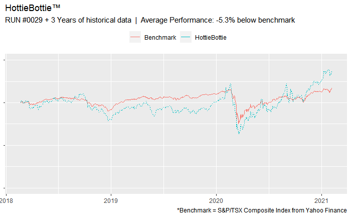

```r
PlotTracker %>%
  ggplot(aes(x = ref.date, y = value)) +
  ylim(0,3000) +
  geom_line(aes(color = variable, linetype = variable)) +
  labs(title = "HottieBottie™",
       subtitle = "RUN #0029 + 3 Years of historical data  |  Average Performance: -5.3% below benchmark",
       caption = "*Benchmark = S&P/TSX Composite Index from Yahoo Finance",
       x = NULL, y = NULL,
       colour = NULL) +
  guides(linetype = "none") +
  theme(legend.position = "top",
        axis.text.y = element_blank())
```